# Event History Modelling: Cabinet Data

Susumu Shikano

2024-02-01

In this markdown, we estimate different event history models by using Alt and King’s (1994) data on cabinet failure.

## Preparation

```r
library(foreign)
library(flexsurv)
```

```r
setwd("../data")


#rawdata <- read.dta("Event_History_Course_Cabinet.dta")
rawdata <- read.csv("coalition2.csv")

rawdata$country[is.na(rawdata$country)] <- "unknown"
```

We can check the raw data:

```r
head(rawdata)
```

```
##   duration ciep12 invest fract polar numst2 crisis country
## 1      0.5      1      1   656    11      0     24 belgium
## 2      3.0      1      1   656    11      1     10 belgium
## 3      7.0      1      1   656    11      1     24 belgium
## 4     20.0      1      1   656    11      1      7 belgium
## 5      6.0      1      1   656    11      1      7 belgium
## 6      7.0      1      1   634     6      1     45 belgium
```

The rows correspond to the individual cabinets (n=314). The data contains the following variables:

- duration: duration
- ciep12: dummy variable whether government is terminated by 12 months prior to the constitutional interelection period
- invest: dummy for legal requirement of legislative investiture vote
- fract: fractionalization
- polar: polarization
- numst2: dummy for government majority in the parliament
- crisis: days needed to form the government
- country: country #- format: formation attempts #- postelec: dummy for post-election #- caretakr: dummy for care taker government

The main outcome variable is $duration$ which measures the duration of the cabinet in month.

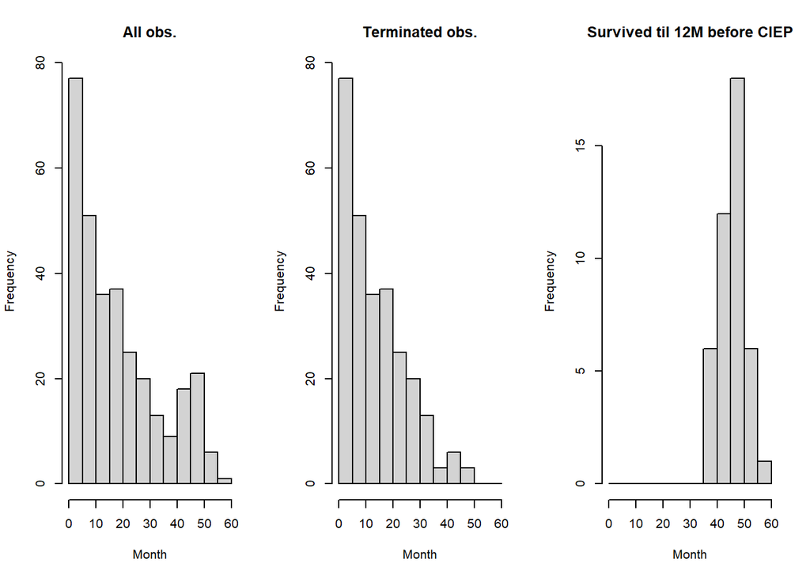

```r
par(mfrow=c(1,3))
hist(rawdata$duration,br=seq(0,60,5),
     main="All obs.",xlab="Month")
hist(rawdata$duration[rawdata$ciep12==1],br=seq(0,60,5),
     main="Terminated obs.",xlab="Month")
hist(rawdata$duration[rawdata$ciep12==0],br=seq(0,60,5),
     main="Survived til 12M before CIEP",xlab="Month")
```

The left-hand panel shows duration of all cabinets in the dataset. The mid panel shows in contrast only the cabinets which were terminated during a legislative period, more exactly speaking by 12 months before the constitutional interelection period (CIEP). And the right-hand panel shows those which survived until 12 months before CIEP.

This specific type of the dependent variable can be processed for event modelling by using $Surv$ function by considering the event variable ($ciep12$):

```r
Surv(rawdata$duration,rawdata$ciep12)
```

```
##   [1]  0.5   3.0   7.0  20.0   6.0   7.0   2.0  17.0  27.0  49.0+  4.0  29.0
##  [13] 49.0+  6.0  23.0  41.0+ 10.0  12.0   2.0  33.0   1.0  16.0   2.0   9.0
##  [25]  3.0   5.0   5.0   6.0  45.0+ 23.0  41.0   7.0  49.0+ 46.0   9.0  51.0+
##  [37] 10.0  32.0  28.0   3.0  53.0+ 17.0  59.0+  9.0  52.0+  3.0  23.0  33.0
##  [49]  1.0  30.0   5.0  16.0  27.0  33.0   9.0  22.0  25.0  25.0  14.0  44.0+
##  [61] 12.0  14.0  13.0  24.0  18.0  13.0  29.0   8.0  16.0  43.0+ 28.0  19.0
##  [73] 10.0   2.0  21.0   4.0   5.0  16.0  15.0   1.0   2.0   2.0   3.0  30.0
##  [85]  8.0  20.0  19.0  21.0  24.0   8.0   7.0   5.0  33.0  10.0   7.0   9.0
##  [97] 13.0  32.0  11.0   3.0  47.0+  5.0   1.0   3.0   5.0   1.0   8.0   1.0
## [109]  0.5  13.0   3.0   5.0   0.5   7.0   4.0   5.0   1.0  10.0   4.0  11.0
## [121]  7.0   0.5  11.0  16.0   4.0   0.5   0.5   5.0   0.5   4.0  33.0  40.0+
## [133] 34.0  28.0  11.0   5.0  43.0+  5.0  43.0+ 37.0+  8.0  36.0  46.0+ 13.0
## [145]  2.0  39.0+ 48.0+ 40.0  35.0  34.0  27.0  28.0  42.0  19.0  32.0  44.0
## [157] 52.0+ 29.0  18.0   7.0   8.0  48.0  11.0   3.0  12.0  18.0   4.0   6.0
## [169] 16.0  13.0  17.0  18.0  10.0  17.0  21.0   8.0   8.0  41.0+  1.0   5.0
## [181] 26.0   4.0  44.0+ 25.0   9.0  25.0   2.0  14.0   3.0  23.0   0.5   5.0
## [193]  0.5  16.0  22.0  13.0   7.0  12.0   4.0  19.0  15.0   5.0   7.0  18.0
## [205] 27.0   5.0   7.0   6.0   3.0   7.0  10.0   0.5  12.0   8.0   7.0  14.0
## [217]  3.0  18.0  11.0   0.5   8.0   6.0   7.0  13.0   3.0   5.0  45.0  30.0
## [229] 15.0  46.0+ 26.0   3.0  48.0+ 19.0  18.0   3.0  49.0+ 13.0   4.0  46.0+
## [241] 41.0+  8.0   3.0  43.0+ 47.0+ 25.0  23.0  15.0  33.0  47.0+ 23.0   1.0
## [253] 25.0  47.0+ 18.0  19.0  12.0  27.0  20.0  41.0+  8.0  19.0  28.0   7.0
## [265]  3.0  17.0   6.0   9.0   2.0  23.0   3.0  24.0   3.0  17.0  22.0  22.0
## [277] 43.0+ 14.0  23.0  36.0  12.0  48.0+ 13.0   7.0  28.0  48.0+ 48.0+ 12.0
## [289] 11.0  36.0+ 36.0+ 24.0  12.0  19.0  16.0  37.0+  5.0  55.0+ 20.0  41.0
## [301]  2.0  19.0  33.0  48.0  12.0  16.0  51.0+ 44.0   7.0  18.0   7.0  30.0
## [313] 50.0+ 49.0+
```

## Why not OLS?

Before estimating the event history models, we can regress the duration variable on the covariates:

```r
summary(lm.out <- lm(duration~ invest + polar +
          numst2 + crisis,
          data=rawdata))
```

```
##
## Call:
## lm(formula = duration ~ invest + polar + numst2 + crisis, data = rawdata)
##
## Residuals:
##     Min      1Q  Median      3Q     Max
## -27.025 -10.007  -1.580   8.609  35.023
##
## Coefficients:
##             Estimate Std. Error t value Pr(>|t|)
## (Intercept) 22.91370    1.55058  14.778  < 2e-16 ***
## invest      -4.55426    1.67950  -2.712 0.007069 **
## polar       -0.46144    0.06554  -7.041 1.24e-11 ***
## numst2       6.07513    1.56335   3.886 0.000125 ***
## crisis       0.03611    0.02099   1.720 0.086352 .
## ---
## Signif. codes:  0 '***' 0.001 '**' 0.01 '*' 0.05 '.' 0.1 ' ' 1
##
## Residual standard error: 13.08 on 309 degrees of freedom
## Multiple R-squared:  0.2645, Adjusted R-squared:  0.255
## F-statistic: 27.78 on 4 and 309 DF,  p-value: < 2.2e-16
```

This analysis does not consider that some cabinets did not experience failure. Therefore, we can exclude such cases and regress again the same outcome variable on the covariates:

```r
only.censored <- rawdata[rawdata$ciep12==1,]
nrow(only.censored)
```

```
## [1] 271
```

```r
summary(lm.out.censored <- lm(duration~ invest + polar +
          numst2 + crisis,
          data=only.censored))
```

```
##
## Call:
## lm(formula = duration ~ invest + polar + numst2 + crisis, data = only.censored)
##
## Residuals:
##     Min      1Q  Median      3Q     Max
## -18.928  -7.937  -1.556   6.612  36.729
##
## Coefficients:
##             Estimate Std. Error t value Pr(>|t|)
## (Intercept) 18.37911    1.27858  14.375  < 2e-16 ***
## invest      -1.67871    1.40077  -1.198   0.2318
## polar       -0.31891    0.05368  -5.940 8.87e-09 ***
## numst2       2.53342    1.28431   1.973   0.0496 *
## crisis       0.01505    0.01951   0.771   0.4413
## ---
## Signif. codes:  0 '***' 0.001 '**' 0.01 '*' 0.05 '.' 0.1 ' ' 1
##
## Residual standard error: 10.16 on 266 degrees of freedom
## Multiple R-squared:  0.1777, Adjusted R-squared:  0.1653
## F-statistic: 14.37 on 4 and 266 DF,  p-value: 1.238e-10
```

If one compares both results, the latter result without cabinets survived until the next election has smaller effects for some covariates (invest, numst2). While the second analysis shows a better diagnostics result (see below), the analysis does not take into account a significant number of cabinets (n=43) in the dataset.

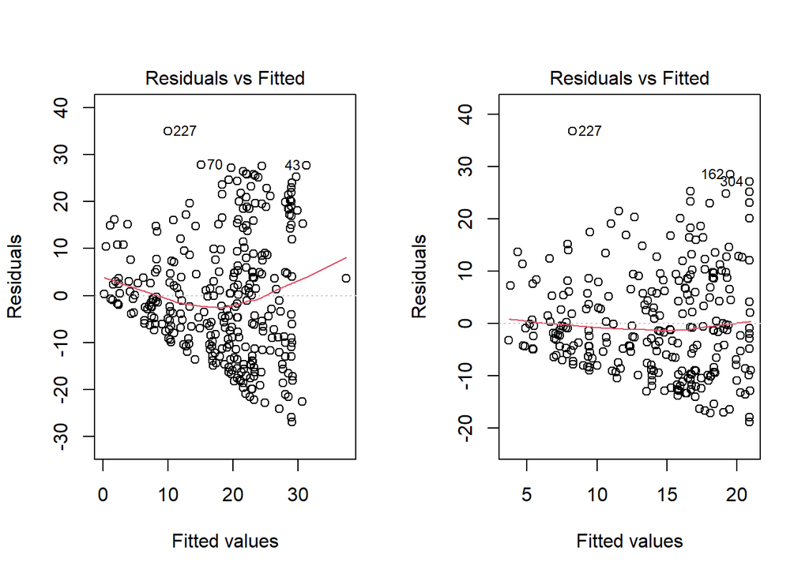

```r
par(mfrow=c(1,2))
plot(lm.out,which=1)
plot(lm.out.censored,which=1)
```

## Some basics of event history models

Differently from the classic regression models which assume normal distributions for the predicted values, event history models assume the other classes of distributions, which are consistent with the important properties of duration such as non-negative values. As such distributions, we can utilize the exponential distributions:

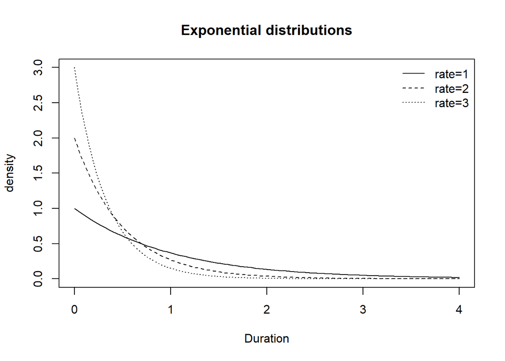

```r
temp.func <- function(x) dexp(x,rate=3)
curve(temp.func,0,4,ylab="density",xlab="Duration",lty=3,main="Exponential distributions")
temp.func <- function(x) dexp(x,rate=2)
curve(temp.func,0,4,add=T,lty=2)
temp.func <- function(x) dexp(x,rate=1)
curve(temp.func,0,4,add=T,lty=1)

legend("topright",
       lty=c(1:3),
       paste0("rate=",c(1:3)),
       col=c(rep("black",3)),
       bty="n")
```

Another possible distribution is the Weibull distributions:

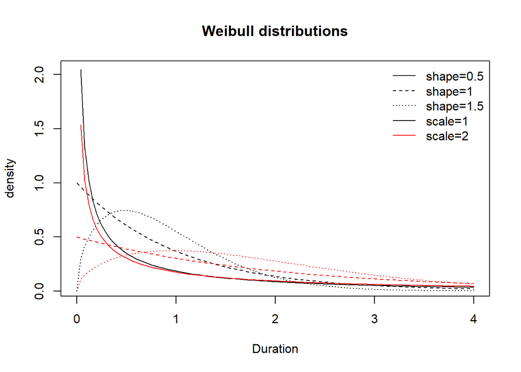

```r
temp.func <- function(x) dweibull(x,shape=0.5,scale=1)
curve(temp.func,0,4,ylab="density",xlab="Duration",main="Weibull distributions")
temp.func <- function(x) dweibull(x,shape=1,scale=1)
curve(temp.func,0,4,add=T,lty=2)
temp.func <- function(x) dweibull(x,shape=1.5,scale=1)
curve(temp.func,0,4,add=T,lty=3)
temp.func <- function(x) dweibull(x,shape=0.5,scale=2)
curve(temp.func,0,4,add=T,col="red")
temp.func <- function(x) dweibull(x,shape=1,scale=2)
curve(temp.func,0,4,add=T,lty=2,col="red")
temp.func <- function(x) dweibull(x,shape=1.5,scale=2)
curve(temp.func,0,4,add=T,lty=3,col="red")

legend("topright",
       lty=c(1,2,3,1,1),
       c(paste0("shape=",c(0.5,1,1.5)),
         paste0("scale=",c(1,2))),
       col=c(rep("black",4),"red"),
       bty="n")
```

### Properties of the exponential distributions

The probability density function of the exponential distribution is defined as follows:

$f(t) = \lambda \exp^{-\lambda t}$

$t$ is a certain possible duration value. $\lambda$ is the only parameter, which is also called the “rate” parameter and has to be larger than zero. As we can see in the above figure, a shorter duration is more likely under an exponential distribution with a higher rate, and vice versa.

We can now integrate the above probability density function to obtain the cumulative distribution function (CDF):

$F(t) = \int^t_0 \lambda \exp^{-\lambda t} d(u) = 1- \exp^{-\lambda t}$

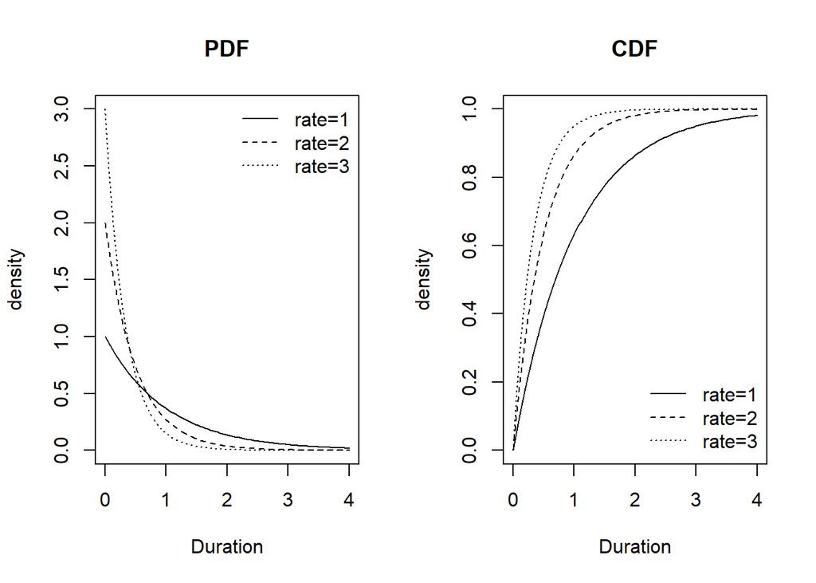

```r
par(mfrow=c(1,2))
temp.func <- function(x) dexp(x,rate=3)
curve(temp.func,0,4,ylab="density",xlab="Duration",lty=3,main="PDF")
temp.func <- function(x) dexp(x,rate=2)
curve(temp.func,0,4,add=T,lty=2)
temp.func <- function(x) dexp(x,rate=1)
curve(temp.func,0,4,add=T,lty=1)

legend("topright",
       lty=c(1:3),
       paste0("rate=",c(1:3)),
       col=c(rep("black",3)),
       bty="n")

temp.func <- function(x) pexp(x,rate=3)
curve(temp.func,0,4,ylab="density",xlab="Duration",lty=3,main="CDF")
temp.func <- function(x) pexp(x,rate=2)
curve(temp.func,0,4,add=T,lty=2)
temp.func <- function(x) pexp(x,rate=1)
curve(temp.func,0,4,add=T,lty=1)

legend("bottomright",
       lty=c(1:3),
       paste0("rate=",c(1:3)),
       col=c(rep("black",3)),
       bty="n")
```

The CDF of a certain duration $t$ corresponds to the probability that duration is exactly $t$ or smaller (Pr(Tt)). Substantively in the context of the event history analysis, it is the probability that the event of interest occurs by $t$. Therefore, its opposite probability is the probability that the event does not occur $t$, which is called the survival probability:

$S(t) = 1- F(t) = \exp^{-\lambda t}$

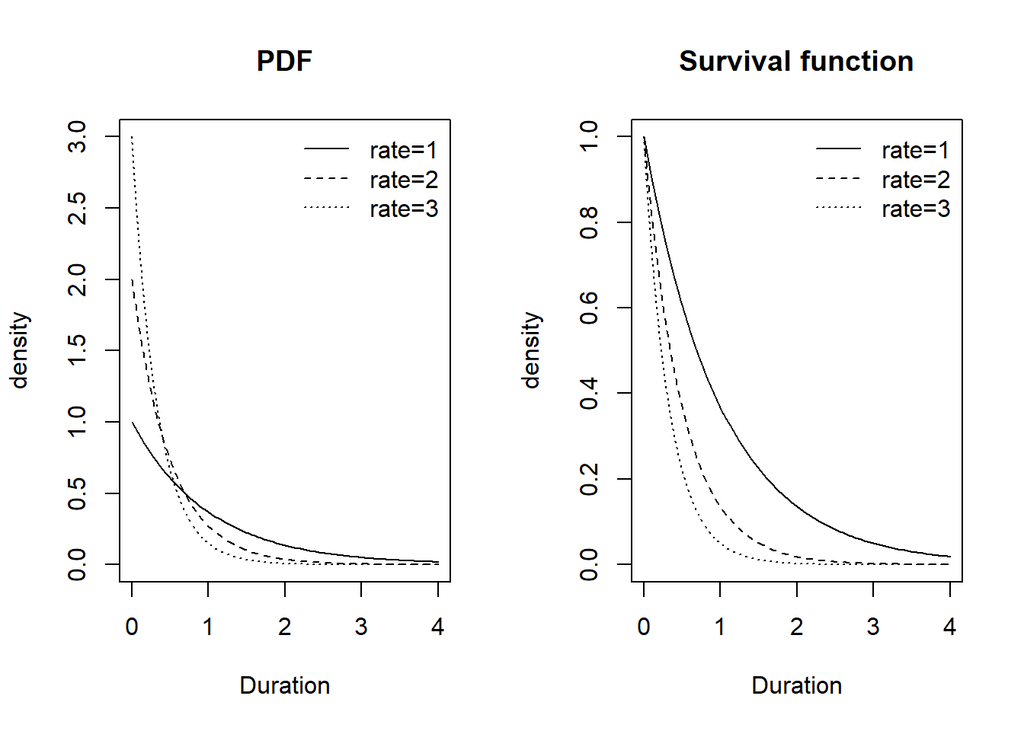

```r
par(mfrow=c(1,2))
temp.func <- function(x) dexp(x,rate=3)
curve(temp.func,0,4,ylab="density",xlab="Duration",lty=3,main="PDF")
temp.func <- function(x) dexp(x,rate=2)
curve(temp.func,0,4,add=T,lty=2)
temp.func <- function(x) dexp(x,rate=1)
curve(temp.func,0,4,add=T,lty=1)

legend("topright",
       lty=c(1:3),
       paste0("rate=",c(1:3)),
       col=c(rep("black",3)),
       bty="n")

temp.func <- function(x) 1-pexp(x,rate=3)
curve(temp.func,0,4,ylab="density",xlab="Duration",lty=3,main="Survival function")
temp.func <- function(x) 1-pexp(x,rate=2)
curve(temp.func,0,4,add=T,lty=2)
temp.func <- function(x) 1-pexp(x,rate=1)
curve(temp.func,0,4,add=T,lty=1)

legend("topright",
       lty=c(1:3),
       paste0("rate=",c(1:3)),
       col=c(rep("black",3)),
       bty="n")
```

Now we consider what the rate parameter of the exponential distributions ($\lambda$) is. From the above functions, it is easy to see that the rate parameter can be obtained by dividing $f(t)$ by $S(T)$:

$\frac{f(t)}{S(T)}=\frac{\lambda \exp^{-\lambda t}}{\exp^{-\lambda t}} = \lambda$

That is, the rate parameter is the probability that we observe the event at $t$ given the event did not occur prior to that. We call such probability hazard or hazard rate and denote it by $h(t)$:

$h(t) = \frac{f(t)}{S(T)}$

It is important to note that the rate parameter is not identical with $f(t)$ as can be seen in the following figure:

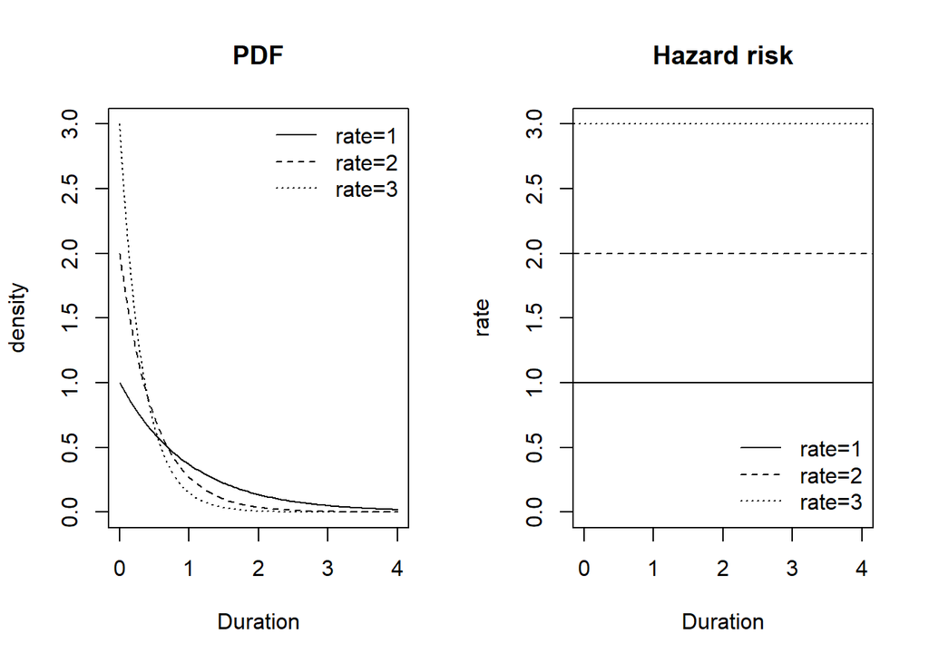

```r
par(mfrow=c(1,2))
temp.func <- function(x) dexp(x,rate=3)
curve(temp.func,0,4,ylab="density",xlab="Duration",lty=3,main="PDF")
temp.func <- function(x) dexp(x,rate=2)
curve(temp.func,0,4,add=T,lty=2)
temp.func <- function(x) dexp(x,rate=1)
curve(temp.func,0,4,add=T,lty=1)

legend("topright",
       lty=c(1:3),
       paste0("rate=",c(1:3)),
       col=c(rep("black",3)),
       bty="n")

plot(0,type="n",xlim=c(0,4),ylim=c(0,3),main="Hazard risk",
     ylab="rate",xlab="Duration")
abline(h=c(1,2,3),lty=c(1:3))

legend("bottomright",
       lty=c(1:3),
       paste0("rate=",c(1:3)),
       col=c(rep("black",3)),
       bty="n")
```

$f(t) = \lambda S(t)$

While $\lambda$ is constant over time, $S(t)$ is always decreasing. Therefore, $f(t)$ is also decreasing.

## Estimating the exponential models

Having seen the properties of the exponential distributions, we are now estimating the effects of covariates on the duration. For this purpose, we have two approaches:

- proportional hazards (PF)
- accelerated failure time (AFT)

We begin with the PF model. In this approach, we estimate the effect of the covariates on the hazard risk. As observed above, if we use the exponential distribution for the duration variable, the hazard risk corresponds to $\lambda$. This hazard can vary among individual observations (e.g. a coalition government has a higher risk to break up, another has a lower risk), however it is constant over time. To model $\lambda_i$ by a certain covariate $x_i$, a straight forward way to link both would be as follows:

$\lambda_i = \beta_0 + \beta_1 x_i$

This function (called “link function”) is however not optimal since $\lambda$ has to be positive while the right-hand side of the equation can produce a negative value. Therefore, we use an alternative link function:

$\lambda_i = \exp(\beta_0 + \beta_1 x_i)$

By using the exponential function, the right-hand side of the equation is always positive.

Below we can find the estimation results of the exponential model with the PH parametrization.

```r
exp.out <- flexsurvreg(Surv(duration,ciep12) ~
                           invest + polar +
                          numst2 + crisis,
                         data=rawdata,
                         dist="exponential")

print(exp.out)
```

```
## Call:
## flexsurvreg(formula = Surv(duration, ciep12) ~ invest + polar +
##     numst2 + crisis, data = rawdata, dist = "exponential")
##
## Estimates:
##         data mean  est        L95%       U95%       se         exp(est)
## rate           NA   0.036996   0.028957   0.047267   0.004625         NA
## invest   0.452229   0.440655   0.173335   0.707975   0.136390   1.553725
## polar   15.289809   0.036034   0.025848   0.046219   0.005197   1.036691
## numst2   0.630573  -0.485218  -0.734315  -0.236120   0.127093   0.615563
## crisis  22.382166  -0.004815  -0.008899  -0.000732   0.002083   0.995197
##         L95%       U95%
## rate           NA         NA
## invest   1.189265   2.029877
## polar    1.026185   1.047304
## numst2   0.479834   0.789686
## crisis   0.991141   0.999269
##
## N = 314,  Events: 271,  Censored: 43
## Total time at risk: 5789.5
## Log-likelihood = -1049.64, df = 5
## AIC = 2109.28
```

Note that the estimated effects are those of the covariate on the risk. For the exponential distribution, its mean is known:

$E(T) = \frac{1}{\lambda}$

Therefore, a positive effect on the risk leads to a negative effect on the duration. For example, the legal requirement of investiture votes increases the risk of the coalition break-up, which leads to a shorter duration of the government.

In contrast to this PH-parametrization, the other AFT approach is more straightforward in interpreting the estimated effect since it links the covariates more directly with the duration:

$\log(T) = \alpha_0 + \alpha_1 X + \epsilon$

For the exponential model, the relationship between the estimated effects ($\alpha$ and $\beta$) is simple:

$\alpha = -\beta$

This can be obtained as follows:

$E(T)= \frac{1}{\lambda} = \frac{1}{\exp(\beta_0 + \beta_1 X)}$

The right-hand side of this equation can be plugged in to the AFT-model:

$\log(T) = log\left(\frac{1}{\exp(\beta_0 + \beta_1 X)}\right) = \log(1) - \log( \exp( (\beta_0 + \beta_1 X)) = - (\beta_0 + \beta_1 X)$

Note that the exponential model with the AFT parametrization is not identical with the linear regression, which regress the logarithmized duration on the same set of covariates:

```r
lm.out <- lm(log(duration) ~
                           invest + polar +
                          numst2 + crisis,
                         data=rawdata)

summary(lm.out)
```

```
##
## Call:
## lm(formula = log(duration) ~ invest + polar + numst2 + crisis,
##     data = rawdata)
##
## Residuals:
##     Min      1Q  Median      3Q     Max
## -2.7766 -0.5949  0.2012  0.6843  1.9823
##
## Coefficients:
##              Estimate Std. Error t value Pr(>|t|)
## (Intercept)  2.753383   0.116343  23.666  < 2e-16 ***
## invest      -0.418834   0.126016  -3.324 0.000995 ***
## polar       -0.033660   0.004917  -6.845 4.12e-11 ***
## numst2       0.504546   0.117301   4.301 2.28e-05 ***
## crisis       0.003040   0.001575   1.930 0.054469 .
## ---
## Signif. codes:  0 '***' 0.001 '**' 0.01 '*' 0.05 '.' 0.1 ' ' 1
##
## Residual standard error: 0.9816 on 309 degrees of freedom
## Multiple R-squared:  0.2794, Adjusted R-squared:  0.2701
## F-statistic: 29.95 on 4 and 309 DF,  p-value: < 2.2e-16
```

- The linear regression with logarithmized duration does not consider the right censored cases.
- The linear regression with logarithmized duration assumes normal distributions for the errors, while the exponential model with AFT assumes another distribution for the errors (extreme value distributions).

### Weibull model

The most important property of the above presented exponential models is that the risk is constant over time. This keeps the model simple, but it is not always appropriate to model empirical data. Therefore, we can switch to another distribution, Weibull distribution. Its PDF is as follows:

$f(t) = \frac{p}{\sigma} \left(\frac{t}{\sigma}\right)^{p-1} \exp^{-\left(\frac{t}{\sigma}\right)^p}$

If one compare this with that of the exponential distribution ($f(t) = \lambda \exp^{-\lambda t}$), the Weibull distribution has two parameters $p$ and $\sigma$. $p$ is called shape parameter, since it determines the shape of the PDF:

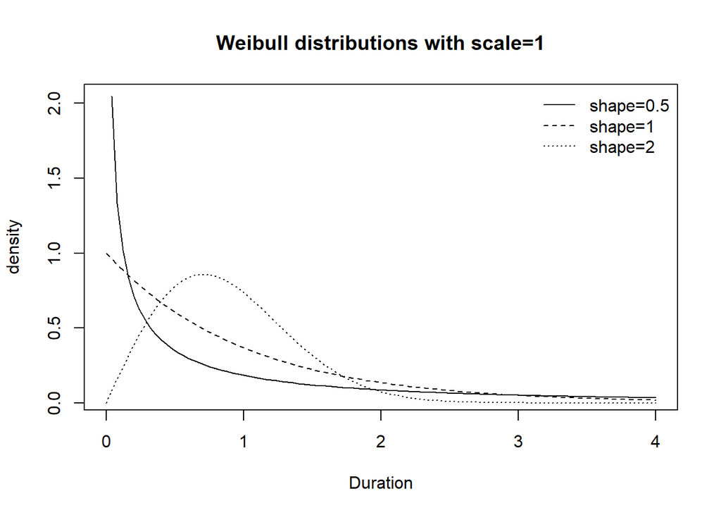

```r
temp.func <- function(x) dweibull(x,shape=0.5,scale=1)
curve(temp.func,0,4,ylab="density",xlab="Duration",main="Weibull distributions with scale=1")
temp.func <- function(x) dweibull(x,shape=1,scale=1)
curve(temp.func,0,4,add=T,lty=2)
temp.func <- function(x) dweibull(x,shape=2,scale=1)
curve(temp.func,0,4,add=T,lty=3)

legend("topright",
       lty=c(1,2,3),
       paste0("shape=",c(0.5,1,2)),
       col=c(rep("black",3)),
       bty="n")
```

If $p=1$ and replace $\sigma$ with the inverse of $\lambda$, the Weibull distribution becomes identical with the exponential distribution. That is, the exponential distribution is a special case of the Weibull distribution.

$\sigma$ is called scale parameter and equivalent to the rate parameter ($\lambda$) of the exponential distribution. However, they are not identical, but they are inverse of the other. While $\lambda$ of the exponential distribution is in a positive relationship with the hazard risk, $\sigma$ of the Weibull distribution is in a negative relationship with the hazard and in a positive relationship with the expected duration.

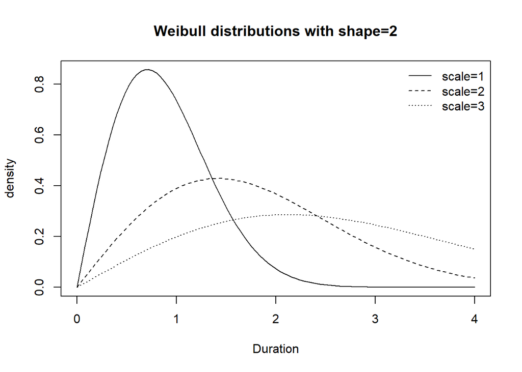

```r
temp.func <- function(x) dweibull(x,shape=2,scale=1)
curve(temp.func,0,4,ylab="density",xlab="Duration",main="Weibull distributions with shape=2")
temp.func <- function(x) dweibull(x,shape=2,scale=2)
curve(temp.func,0,4,add=T,lty=2)
temp.func <- function(x) dweibull(x,shape=2,scale=3)
curve(temp.func,0,4,add=T,lty=3)

legend("topright",
       lty=c(1,2,3),
       paste0("scale=",c(1,2,3)),
       col=c(rep("black",3)),
       bty="n")
```

By applying the same procedure above, we can obtain the survival function:

$S(t) = \exp^{-\left(\frac{t}{\sigma}\right)^p}$

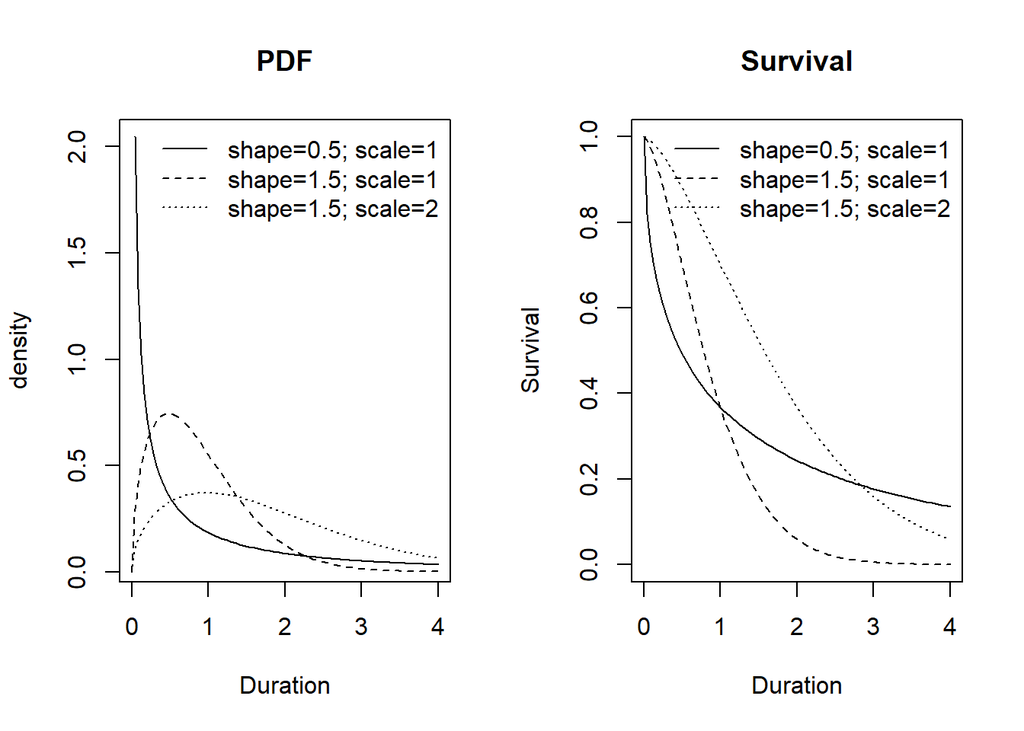

```r
par(mfrow=c(1,2))
temp.func <- function(x) dweibull(x,shape=0.5,scale=1)
curve(temp.func,0,4,ylab="density",xlab="Duration",main="PDF")
temp.func <- function(x) dweibull(x,shape=1.5,scale=1)
curve(temp.func,0,4,add=T,lty=2)
temp.func <- function(x) dweibull(x,shape=1.5,scale=2)
curve(temp.func,0,4,add=T,lty=3)

legend("topright",
       lty=c(1,2,3),
       paste0("shape=",c(0.5,1.5,1.5),"; scale=",c(1,1,2)),
       col=c(rep("black",3)),
       bty="n")

temp.func <- function(x) 1-pweibull(x,shape=0.5,scale=1)
curve(temp.func,0,4,ylab="Survival",xlab="Duration",main="Survival",ylim=c(0,1))
temp.func <- function(x) 1-pweibull(x,shape=1.5,scale=1)
curve(temp.func,0,4,add=T,lty=2)
temp.func <- function(x) 1-pweibull(x,shape=1.5,scale=2)
curve(temp.func,0,4,add=T,lty=3)

legend("topright",
       lty=c(1,2,3),
       paste0("shape=",c(0.5,1.5,1.5),"; scale=",c(1,1,2)),
       col=c(rep("black",3)),
       bty="n")
```

By dividing $f(t)$ by $S(t)$, we obtain the hazard function for the Weibull model:

$h(t) = \frac{p}{\sigma}\left(\frac{t}{\sigma}\right)^{p-1} = p t^{p-1} \left(\frac{1}{\sigma}\right)^p$

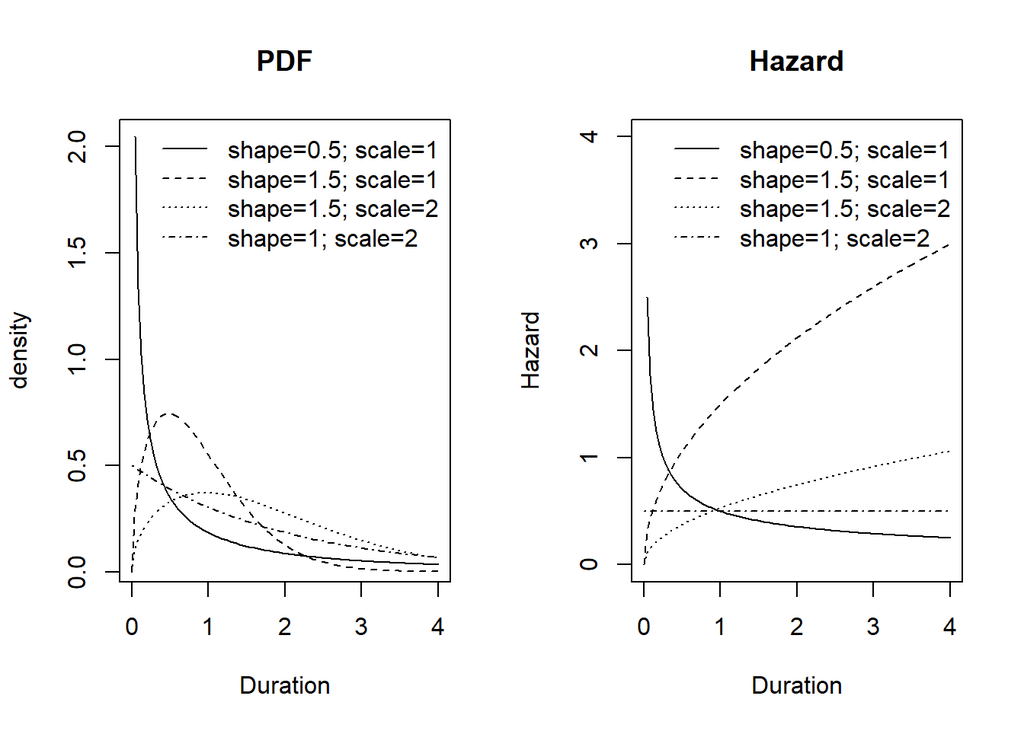

```r
par(mfrow=c(1,2))
temp.func <- function(x) dweibull(x,shape=0.5,scale=1)
curve(temp.func,0,4,ylab="density",xlab="Duration",main="PDF")
temp.func <- function(x) dweibull(x,shape=1.5,scale=1)
curve(temp.func,0,4,add=T,lty=2)
temp.func <- function(x) dweibull(x,shape=1.5,scale=2)
curve(temp.func,0,4,add=T,lty=3)
temp.func <- function(x) dweibull(x,shape=1,scale=2)
curve(temp.func,0,4,add=T,lty=4)

legend("topright",
       lty=c(1:4),
       paste0("shape=",c(0.5,1.5,1.5,1),"; scale=",c(1,1,2,2)),
       col=c(rep("black",4)),
       bty="n")

weibull.hazard <- function(x,shape,scale){
  (shape/scale) * ((x/scale)^(shape-1) )
}
temp.func <- function(x) weibull.hazard(x,shape=0.5,scale=1)
curve(temp.func,0,4,ylab="Hazard",xlab="Duration",main="Hazard",ylim=c(0,4))
temp.func <- function(x) weibull.hazard(x,shape=1.5,scale=1)
curve(temp.func,0,4,add=T,lty=2)
temp.func <- function(x) weibull.hazard(x,shape=1.5,scale=2)
curve(temp.func,0,4,add=T,lty=3)
temp.func <- function(x) weibull.hazard(x,shape=1,scale=2)
curve(temp.func,0,4,add=T,lty=4)


legend("topright",
       lty=c(1:4),
       paste0("shape=",c(0.5,1.5,1.5,1),"; scale=",c(1,1,2,2)),
       col=c(rep("black",4)),
       bty="n")
```

As is clear in the figure above, the hazard function can be increasing or decreasing depending on the shape parameter. In case that the shape parameter is one, the function is constant over time, which is equivalent to the exponential distribution. In this case, the hazard rate takes the inverse of the scale parameter, therefore 1/2.

### Estimation of the Weibull model

Like the exponential model, the Weibull model can be estimated in two ways: PH and AFT.

The PH parametrization links the hazard with the covariate. The Weibull model’s hazard is as follows:

$h(t) = p t^{p-1} \left(\frac{1}{\sigma}\right)^p$

In this function, we link the covariates with the last term, $\left(\frac{1}{\sigma}\right)^p$. This part include the inverse of $\sigma$ which corresponds to $\lambda$ in the exponential model. As is the case in the exponential model, we assume that individual observations differ in this component and linked to the covariate, therefore:

$\left(\frac{1}{\sigma_i}\right)^p = \exp(\beta_0 + \beta_1 x_i)$.

In contrast to $\sigma_i$, the shape parameter $p$ is estimated under the assumption that it is constant for all observations.

```r
weibull.ph.out <- flexsurvreg(Surv(duration,ciep12) ~
                           invest + polar +
                          numst2 + crisis,
                         data=rawdata,
                         dist="weibullph")

print(weibull.ph.out)
```

```
## Call:
## flexsurvreg(formula = Surv(duration, ciep12) ~ invest + polar +
##     numst2 + crisis, data = rawdata, dist = "weibullph")
##
## Estimates:
##         data mean  est       L95%      U95%      se        exp(est)  L95%
## shape         NA    1.15619   1.04851   1.27493   0.05767        NA        NA
## scale         NA    0.02185   0.01386   0.03443   0.00507        NA        NA
## invest   0.45223    0.47616   0.20845   0.74386   0.13659   1.60988   1.23177
## polar   15.28981    0.04018   0.02958   0.05079   0.00541   1.04100   1.03002
## numst2   0.63057   -0.52530  -0.77612  -0.27448   0.12797   0.59138   0.46019
## crisis  22.38217   -0.00540  -0.00956  -0.00124   0.00212   0.99462   0.99049
##         U95%
## shape         NA
## scale         NA
## invest   2.10404
## polar    1.05210
## numst2   0.75997
## crisis   0.99876
##
## N = 314,  Events: 271,  Censored: 43
## Total time at risk: 5789.5
## Log-likelihood = -1045.671, df = 6
## AIC = 2103.341
```

The estimated effects of the covariates on the hazard rate are quite similar to those of the exponential model (see below).

```r
print(exp.out)
```

```
## Call:
## flexsurvreg(formula = Surv(duration, ciep12) ~ invest + polar +
##     numst2 + crisis, data = rawdata, dist = "exponential")
##
## Estimates:
##         data mean  est        L95%       U95%       se         exp(est)
## rate           NA   0.036996   0.028957   0.047267   0.004625         NA
## invest   0.452229   0.440655   0.173335   0.707975   0.136390   1.553725
## polar   15.289809   0.036034   0.025848   0.046219   0.005197   1.036691
## numst2   0.630573  -0.485218  -0.734315  -0.236120   0.127093   0.615563
## crisis  22.382166  -0.004815  -0.008899  -0.000732   0.002083   0.995197
##         L95%       U95%
## rate           NA         NA
## invest   1.189265   2.029877
## polar    1.026185   1.047304
## numst2   0.479834   0.789686
## crisis   0.991141   0.999269
##
## N = 314,  Events: 271,  Censored: 43
## Total time at risk: 5789.5
## Log-likelihood = -1049.64, df = 5
## AIC = 2109.28
```

As discussed above, the difference between both models primarily lies in the shape parameter. If the shape parameter is one, the Weibull model is equivalent to the exponential model. According the above estimation results, the shape parameter is above 1 in its point estimate as well as its 95% confidence interval. This means, the hazard function is not constant, but slightly increasing.

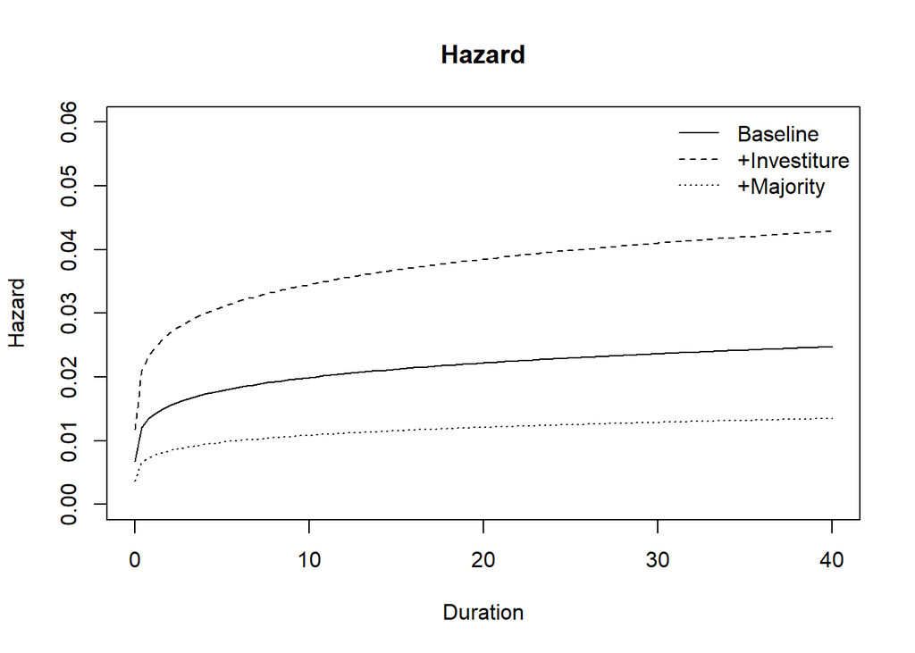

```r
temp.func <- function(x) weibull.hazard(x,
                                  shape=exp(coefficients(weibull.ph.out)["shape"]),
                                  scale=1/exp(coefficients(weibull.ph.out)["scale"]))
curve(temp.func,0.01,40,ylab="Hazard",xlab="Duration",main="Hazard",ylim=c(0,.06))
temp.func <- function(x) weibull.hazard(x,
                                  shape=exp(coefficients(weibull.ph.out)["shape"]),
                                  scale=1/exp(coefficients(weibull.ph.out)["scale"]+
                                              coefficients(weibull.ph.out)["invest"]  ))
curve(temp.func,0.01,40,add=T,lty=2)
temp.func <- function(x) weibull.hazard(x,
                                  shape=exp(coefficients(weibull.ph.out)["shape"]),
                                  scale=1/exp(coefficients(weibull.ph.out)["scale"]+
                                              coefficients(weibull.ph.out)["numst2"]  ))
curve(temp.func,0.01,40,add=T,lty=3)

legend("topright",
       lty=c(1:3),
       c("Baseline","+Investiture","+Majority"),
       col=c(rep("black",3)),
       bty="n")
```

In the above figure, all the hazard functions are proportional to each other. That is, the ratio between any two hazard functions are constant over time. This is also the case in the exponential model since the hazard functions are flat so that their ratio is always identical. This property is called the proportional hazard property. By using this property, the PH parametrization estimate the effects of covariates on the hazard functions.

While the estimated effects based on the PH parametrization is straightforward in terms of the hazard, their relationship with the expected duration is not intuitive since the expected value of the Weibull model is as follows:

$E(T) = \sigma \Gamma\left( 1+ \frac{1}{p} \right)$

The expected duration can be more directly linked with the covariates by using the AFT approach:

$\log(T) = \alpha_0 + \alpha_1 X + \frac{\epsilon}{p}$

with $\epsilon$ being the extreme value distribution.

```r
est.res <- flexsurvreg(Surv(duration,ciep12) ~
                           invest + polar +
                          numst2 + crisis,
                         data=rawdata,
                         dist="weibull")

print(est.res)
```

```
## Call:
## flexsurvreg(formula = Surv(duration, ciep12) ~ invest + polar +
##     numst2 + crisis, data = rawdata, dist = "weibull")
##
## Estimates:
##         data mean  est       L95%      U95%      se        exp(est)  L95%
## shape         NA    1.15619   1.04851   1.27493   0.05767        NA        NA
## scale         NA   27.30559  22.09497  33.74501   2.94991        NA        NA
## invest   0.45223   -0.41183  -0.64312  -0.18054   0.11801   0.66244   0.52565
## polar   15.28981   -0.03475  -0.04360  -0.02591   0.00451   0.96584   0.95734
## numst2   0.63057    0.45433   0.23792   0.67075   0.11042   1.57512   1.26860
## crisis  22.38217    0.00467   0.00108   0.00825   0.00183   1.00468   1.00108
##         U95%
## shape         NA
## scale         NA
## invest   0.83482
## polar    0.97443
## numst2   1.95571
## crisis   1.00829
##
## N = 314,  Events: 271,  Censored: 43
## Total time at risk: 5789.5
## Log-likelihood = -1045.671, df = 6
## AIC = 2103.341
```

The estimated shape parameter is identical between both parametrizations. The estimated effects of the covariates have the other sign, which is reasonable since PH links the covariates with the hazard while AFT links them with the expected duration. Between both sets of the extimates, the following relationship is known:

$\beta= - \alpha p$

## Parameter estimation via maximum likelihood

For data with the full duration time, that is, if all observations have the exact measured duration, building the likelihood function is straightforward:

$\mathfrak{L} = \prod^n_{i=1} f(t_i)$

If we have right-censored cases, however, their likelihood is differently obtained by using the survival rate:

$\mathfrak{L} = \prod^n_{i=1} \left\{ f(t_i) \right\}^{\delta_i} \left\{ S(t_i) \right\}^{1-\delta_i}$

$\delta_i$ is the dummy variable whether the event takes place in the observation $i$ or not.

## Relationship between f(t), S(t) and h(t) in general

Above we have seen the relationship between $f(t)$, $S(t)$ and $h(t)$ for the exponential and Weibull models. Here, we examine their relationship in a more general way.

Per definition, the following is known:

- Survival rate: $S(t) = 1-F(t) = 1- \int^t_0 \lambda \exp(-\lambda t) d(u)$
- hazard rate: $h(t) = \frac{f(t)}{S(t)}$

From both equations, we can further derive the following:

- $f(t) =\frac{dF(t)}{d(t)} = \frac{-dS(t)}{d(t)}$
- $h(t) =\frac{-dS(t)}{d(t)}/S(t) = \frac{-d \log S(t)}{dt}$
- $H(t) \equiv \int^t_0 h(u) du=-\log S(t)$
- $S(t) =\exp\left( -\int^t_0 h(u) du \right) = \exp(-H(t))$
- $f(t) =h(t)S(t)=h(t)\exp(-H(t))$

## Estimating further parametric models

We estimate the following six parametric models:

- Exponential
- Weibull
- log normal
- log logistic
- Gompertz
- Generalized gamma.

```r
model.label <- c("exponential",
              "weibull",
              "lnorm",
              "llogis",
              "gompertz",
              "gengamma")

all.para.out <- vector("list",length(model.label))

for (i.model in 1:length(model.label)){

est.res <- flexsurvreg(Surv(duration,ciep12) ~
                           invest + polar +
                          numst2 + crisis,
                         data=rawdata,
                         dist=model.label[i.model])
all.para.out[[i.model]] <- list(model=model.label[i.model],
                                est=est.res)

print("-------------------------------------------")
print(paste("MODEL:",model.label[i.model]))
print(est.res)
}
```

```
## [1] "-------------------------------------------"
## [1] "MODEL: exponential"
## Call:
## flexsurvreg(formula = Surv(duration, ciep12) ~ invest + polar +
##     numst2 + crisis, data = rawdata, dist = model.label[i.model])
##
## Estimates:
##         data mean  est        L95%       U95%       se         exp(est)
## rate           NA   0.036996   0.028957   0.047267   0.004625         NA
## invest   0.452229   0.440655   0.173335   0.707975   0.136390   1.553725
## polar   15.289809   0.036034   0.025848   0.046219   0.005197   1.036691
## numst2   0.630573  -0.485218  -0.734315  -0.236120   0.127093   0.615563
## crisis  22.382166  -0.004815  -0.008899  -0.000732   0.002083   0.995197
##         L95%       U95%
## rate           NA         NA
## invest   1.189265   2.029877
## polar    1.026185   1.047304
## numst2   0.479834   0.789686
## crisis   0.991141   0.999269
##
## N = 314,  Events: 271,  Censored: 43
## Total time at risk: 5789.5
## Log-likelihood = -1049.64, df = 5
## AIC = 2109.28
##
## [1] "-------------------------------------------"
## [1] "MODEL: weibull"
## Call:
## flexsurvreg(formula = Surv(duration, ciep12) ~ invest + polar +
##     numst2 + crisis, data = rawdata, dist = model.label[i.model])
##
## Estimates:
##         data mean  est       L95%      U95%      se        exp(est)  L95%
## shape         NA    1.15619   1.04851   1.27493   0.05767        NA        NA
## scale         NA   27.30559  22.09497  33.74501   2.94991        NA        NA
## invest   0.45223   -0.41183  -0.64312  -0.18054   0.11801   0.66244   0.52565
## polar   15.28981   -0.03475  -0.04360  -0.02591   0.00451   0.96584   0.95734
## numst2   0.63057    0.45433   0.23792   0.67075   0.11042   1.57512   1.26860
## crisis  22.38217    0.00467   0.00108   0.00825   0.00183   1.00468   1.00108
##         U95%
```

[output cut: 106 more lines]

```
## numst2   0.630573   0.498508   0.257851   0.739165   0.122786   1.646263
## crisis  22.382166   0.004413   0.000779   0.008046   0.001854   1.004422
##         L95%       U95%
## mu             NA         NA
## sigma          NA         NA
## Q              NA         NA
## invest   0.497016   0.824886
## polar    0.955322   0.974026
## numst2   1.294146   2.094186
## crisis   1.000779   1.008079
##
## N = 314,  Events: 271,  Censored: 43
## Total time at risk: 5789.5
## Log-likelihood = -1044.063, df = 7
## AIC = 2102.126
```

We can plot the hazard functions with 95% confidence intervals (red) against kernel-based smooth nonparametric hazard (black):

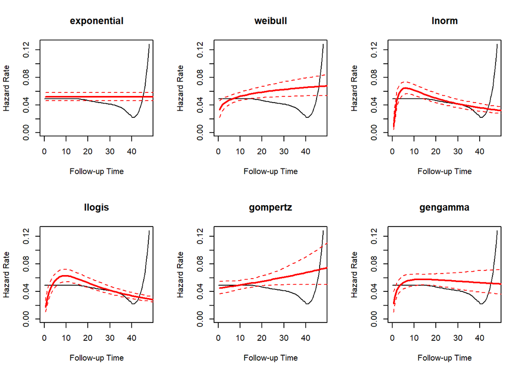

```r
par(mfrow=c(2,3))
for (i.model in 1:length(model.label)){
  plot(all.para.out[[i.model]]$est,type="hazard",
       main=model.label[i.model])
}
```

We can plot the survival functions:

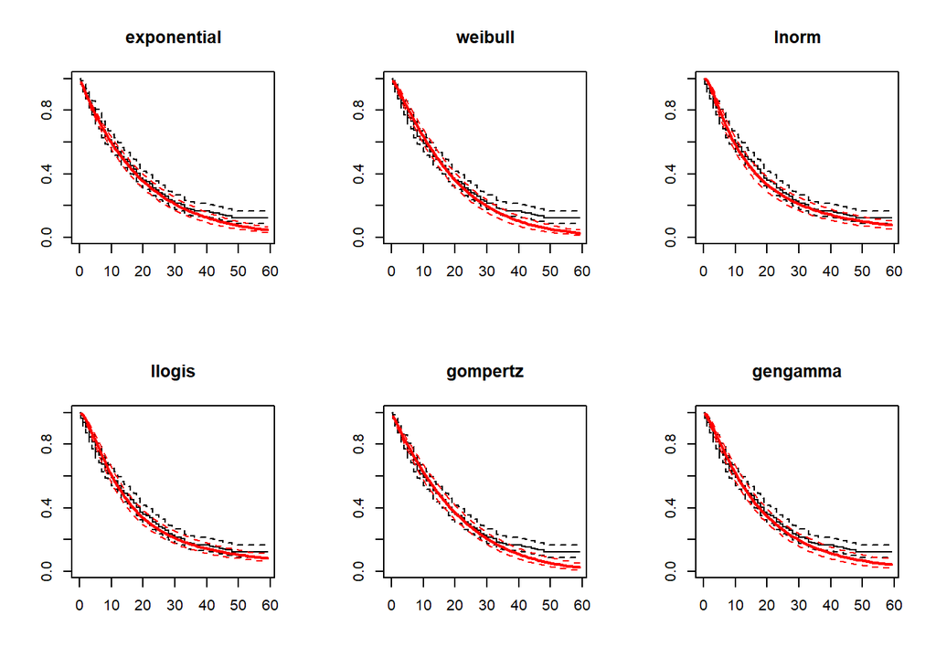

```r
par(mfrow=c(2,3))
for (i.model in 1:length(model.label)){
  plot(all.para.out[[i.model]]$est,type="survival",
       main=model.label[i.model])
}
```

## Cox PH model

We can now switch to Cox PH model keeping the covariate constant:

```r
est.res <- coxph(Surv(duration,ciep12) ~
                           invest + polar +
                          numst2 + crisis,data=rawdata)
print(est.res)
```

```
## Call:
## coxph(formula = Surv(duration, ciep12) ~ invest + polar + numst2 +
##     crisis, data = rawdata)
##
##             coef exp(coef)  se(coef)      z        p
## invest  0.477237  1.611616  0.136486  3.497 0.000471
## polar   0.039936  1.040744  0.005485  7.282 3.30e-13
## numst2 -0.506027  0.602886  0.128464 -3.939 8.18e-05
## crisis -0.005312  0.994702  0.002133 -2.491 0.012745
##
## Likelihood ratio test=104.2  on 4 df, p=< 2.2e-16
## n= 314, number of events= 271
```

We can now check the situation at individual time points:

```r
summary(survfit(est.res))
```

```
## Call: survfit(formula = est.res)
##
##  time n.risk n.event survival std.err lower 95% CI upper 95% CI
##   0.5    314      11   0.9692 0.00964       0.9505        0.988
##   1.0    303       9   0.9428 0.01364       0.9164        0.970
##   2.0    294      10   0.9130 0.01735       0.8796        0.948
##   3.0    284      19   0.8557 0.02333       0.8112        0.903
##   4.0    265      10   0.8248 0.02616       0.7751        0.878
##   5.0    255      18   0.7664 0.03097       0.7081        0.830
##   6.0    237       7   0.7428 0.03272       0.6814        0.810
##   7.0    230      18   0.6804 0.03672       0.6121        0.756
##   8.0    212      12   0.6378 0.03897       0.5658        0.719
##   9.0    200       7   0.6129 0.04012       0.5391        0.697
##  10.0    193       7   0.5880 0.04115       0.5126        0.674
##  11.0    186       7   0.5626 0.04206       0.4859        0.651
##  12.0    179      10   0.5259 0.04315       0.4478        0.618
##  13.0    169      10   0.4887 0.04398       0.4097        0.583
##  14.0    159       5   0.4696 0.04430       0.3903        0.565
##  15.0    154       4   0.4541 0.04450       0.3747        0.550
##  16.0    150       9   0.4187 0.04474       0.3396        0.516
##  17.0    141       6   0.3949 0.04473       0.3162        0.493
##  18.0    135       9   0.3592 0.04446       0.2818        0.458
##  19.0    126       9   0.3231 0.04384       0.2477        0.422
##  20.0    117       4   0.3072 0.04346       0.2329        0.405
##  21.0    113       3   0.2955 0.04312       0.2220        0.393
##  22.0    110       4   0.2798 0.04258       0.2076        0.377
##  23.0    106       8   0.2481 0.04120       0.1791        0.344
##  24.0     98       4   0.2324 0.04037       0.1654        0.327
##  25.0     94       6   0.2095 0.03898       0.1455        0.302
##  26.0     88       2   0.2020 0.03847       0.1391        0.293
##  27.0     86       5   0.1835 0.03707       0.1235        0.273
##  28.0     81       6   0.1618 0.03515       0.1057        0.248
##  29.0     75       3   0.1512 0.03411       0.0972        0.235
##  30.0     72       4   0.1374 0.03265       0.0862        0.219
##  32.0     68       3   0.1272 0.03151       0.0783        0.207
##  33.0     65       7   0.1047 0.02862       0.0613        0.179
##  34.0     58       2   0.0985 0.02773       0.0568        0.171
##  35.0     56       1   0.0955 0.02727       0.0546        0.167
##  36.0     55       2   0.0896 0.02634       0.0503        0.159
##  40.0     48       1   0.0863 0.02585       0.0479        0.155
##  41.0     46       2   0.0795 0.02482       0.0431        0.147
##  42.0     40       1   0.0760 0.02427       0.0406        0.142
##  44.0     34       2   0.0676 0.02303       0.0347        0.132
##  45.0     30       1   0.0633 0.02232       0.0317        0.126
##  46.0     28       1   0.0584 0.02154       0.0284        0.120
##  48.0     20       2   0.0467 0.01963       0.0205        0.106
```

At each time point, the table above gives the number of observations at risk, number of the observed events, the resulting survival rate and their variance/interval estimate.

Due to the rough data (unit = month), we have tie events at most time points.

We can now plot the survival function and the cumulative hazard function. The first plot is based on the empirical data, the other plot on the right-hand side is based on the hypothetical situation where:

- there is legal requirement of investiture vote. # - there is no polarization.
- the cabinet has a parliamentary majority.
- the coalition negotiation took 30 days. #- the cabinet has formed after the first attempt right after a parliamentary election. #- the cabinet is not a care taker government.

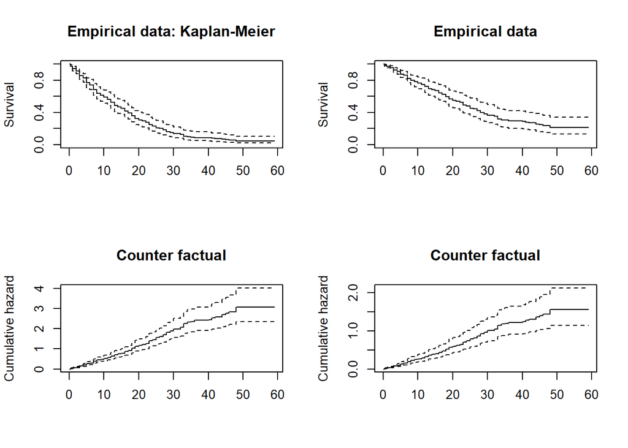

```r
par(mfrow=c(2,2))
plot(survfit(est.res),main="Empirical data: Kaplan-Meier",ylab="Survival")
plot(survfit(est.res,
             newdata=data.frame(invest=1,polar=0,numst2=1,crisis=30
                                )),main="Empirical data",ylab="Survival")

plot(survfit(est.res),fun="cumhaz",main="Counter factual",ylab="Cumulative hazard")
plot(survfit(est.res,
             newdata=data.frame(invest=1,polar=0,numst2=1,crisis=30
                                )),fun="cumhaz",main="Counter factual",ylab="Cumulative hazard")
```

Both upper panels show the survival function based on the empirical data (the left panel) and the counter-factual scenario stated above (the right panel). The left-hand side plot is based on the simple Kaplan-Meier-estimator: $\hat S (t) = \prod_{i=1}^{t-1} \left(1-\frac{d_i}{n_i} \right)$ with $i \in \{1, \ldots, K\}$ being the time points when at least one event was observed. $d_i$ is the number of event at $t_i$ and $n_i$ is the size of the risk set at $t_i$.

The lower panels show the cumultative hazard function. Due to the proportional hazard property, both functions have the same form, but they differ in the scale (see the y-axis of both panels.)

We can also compare the effect of requirement of investiture votes where the other variables are kept to be the mean:

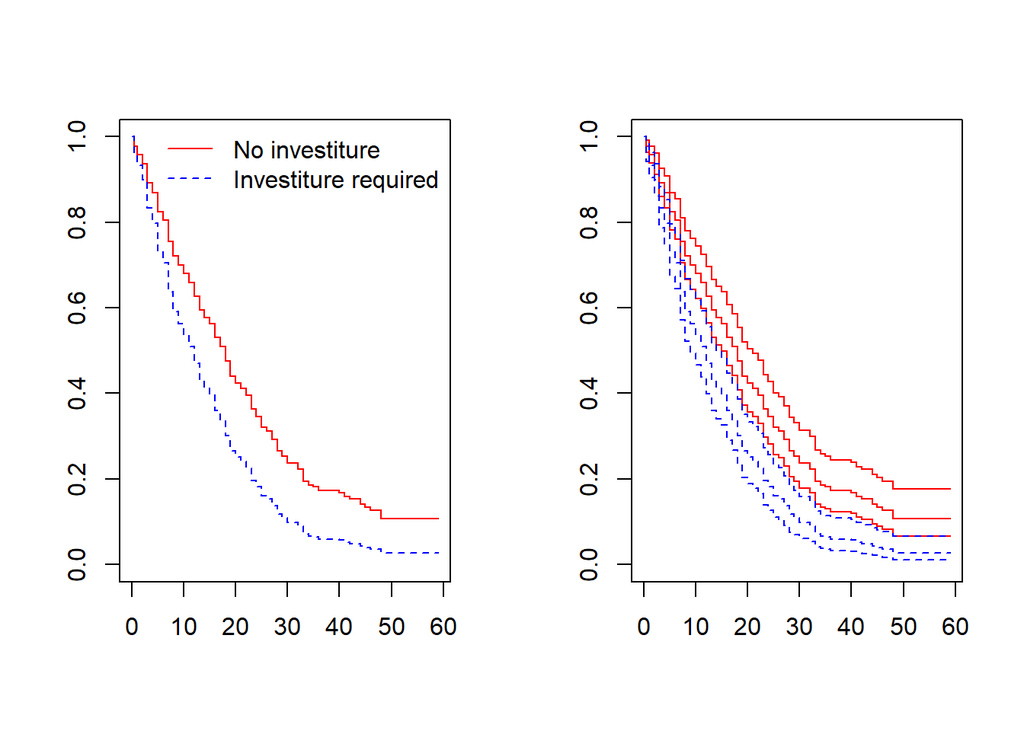

```r
par(mfrow=c(1,2))
new.dat <- data.frame(invest=c(0,1), polar=rep(mean(rawdata$polar),2),
                       fract=rep(mean(rawdata$fract),2),
                       numst2=rep(mean(rawdata$numst2),2),
                       crisis=rep(mean(rawdata$crisis),2))
plot(survfit(est.res,newdata=new.dat),
                            lty=c(1,2),col=c("red","blue"))
legend("topright",col=c("red","blue"),lty=c(1,2),c("No investiture","Investiture required"),bty="n")
plot(survfit(est.res,newdata=new.dat),conf.int=T,
                            lty=c(1,2),col=c("red","blue"))
```

As we have seen above, there are many tie events due to the duration measure based on month. To deal with such tie events, there are several possibilities, among which the following solutions are implemented in the survival package:

- Efron method (default and the result above)
- Breslow method
- Exact partial likelihood

```r
est.res <- coxph(Surv(duration,ciep12) ~ invest + polar +
              numst2 + crisis,data=rawdata,
              ties="efron")
print(est.res)
```

```
## Call:
## coxph(formula = Surv(duration, ciep12) ~ invest + polar + numst2 +
##     crisis, data = rawdata, ties = "efron")
##
##             coef exp(coef)  se(coef)      z        p
## invest  0.477237  1.611616  0.136486  3.497 0.000471
## polar   0.039936  1.040744  0.005485  7.282 3.30e-13
## numst2 -0.506027  0.602886  0.128464 -3.939 8.18e-05
## crisis -0.005312  0.994702  0.002133 -2.491 0.012745
##
## Likelihood ratio test=104.2  on 4 df, p=< 2.2e-16
## n= 314, number of events= 271
```

```r
est.res <- coxph(Surv(duration,ciep12) ~ invest + polar +
              numst2 + crisis,data=rawdata,
              ties="breslow")
print(est.res)
```

```
## Call:
## coxph(formula = Surv(duration, ciep12) ~ invest + polar + numst2 +
##     crisis, data = rawdata, ties = "breslow")
##
##             coef exp(coef)  se(coef)      z        p
## invest  0.464896  1.591849  0.136721  3.400 0.000673
## polar   0.038452  1.039201  0.005477  7.021  2.2e-12
## numst2 -0.495260  0.609413  0.128480 -3.855 0.000116
## crisis -0.005057  0.994955  0.002120 -2.385 0.017071
##
## Likelihood ratio test=98.36  on 4 df, p=< 2.2e-16
## n= 314, number of events= 271
```

```r
est.res <- coxph(Surv(duration,ciep12) ~ invest + polar +
              numst2 + crisis,data=rawdata,
              ties="exact")
print(est.res)
```

```
## Call:
## coxph(formula = Surv(duration, ciep12) ~ invest + polar + numst2 +
##     crisis, data = rawdata, ties = "exact")
##
##             coef exp(coef)  se(coef)      z        p
## invest  0.499325  1.647608  0.140566  3.552 0.000382
## polar   0.041353  1.042220  0.005699  7.257 3.97e-13
## numst2 -0.533184  0.586734  0.133768 -3.986 6.72e-05
## crisis -0.005337  0.994677  0.002192 -2.435 0.014896
##
## Likelihood ratio test=104.6  on 4 df, p=< 2.2e-16
## n= 314, number of events= 271
```

In our case, fortunately, the different methods do not produce any significant differences between the estimates.

## Discrete time modelling

### Converting data into the counting process style

We convert the original data into the counting process format. For this purpose, the survSplit function is useful:

```r
id <- 1:dim(rawdata)[1]
rawdata.with.id <- cbind(id,rawdata)

# --------------------------------------------------------------------------
# For time varying covariates
cut.points <- seq(0.5,max(rawdata$duration),by=0.5)
cp.data <- survSplit(data = rawdata.with.id, cut = cut.points,
     end = "duration",start = "time0", event = "ciep12")

cp.data <- cp.data[order(cp.data$id),]

head(cp.data,n=10)
```

```
##    id invest fract polar numst2 crisis country time0 duration ciep12
## 1   1      1   656    11      0     24 belgium   0.0      0.5      1
## 2   2      1   656    11      1     10 belgium   0.0      0.5      0
## 3   2      1   656    11      1     10 belgium   0.5      1.0      0
## 4   2      1   656    11      1     10 belgium   1.0      1.5      0
## 5   2      1   656    11      1     10 belgium   1.5      2.0      0
## 6   2      1   656    11      1     10 belgium   2.0      2.5      0
## 7   2      1   656    11      1     10 belgium   2.5      3.0      1
## 8   3      1   656    11      1     24 belgium   0.0      0.5      0
## 9   3      1   656    11      1     24 belgium   0.5      1.0      0
## 10  3      1   656    11      1     24 belgium   1.0      1.5      0
```

For comparison, you can check the original data again:

```r
head(rawdata.with.id)
```

```
##   id duration ciep12 invest fract polar numst2 crisis country
## 1  1      0.5      1      1   656    11      0     24 belgium
## 2  2      3.0      1      1   656    11      1     10 belgium
## 3  3      7.0      1      1   656    11      1     24 belgium
## 4  4     20.0      1      1   656    11      1      7 belgium
## 5  5      6.0      1      1   656    11      1      7 belgium
## 6  6      7.0      1      1   634     6      1     45 belgium
```

### Binary logit model with counting process data

To the counting process data, we can just apply the binary logit model to estimate an event model:

```r
est.res <- glm(ciep12 ~ invest + polar +
              numst2 + crisis ,data=cp.data,family=binomial(link="logit"))
summary(est.res)
```

```
##
## Call:
## glm(formula = ciep12 ~ invest + polar + numst2 + crisis, family = binomial(link = "logit"),
##     data = cp.data)
##
## Coefficients:
##              Estimate Std. Error z value Pr(>|z|)
## (Intercept) -3.971050   0.126656 -31.353  < 2e-16 ***
## invest       0.457118   0.138192   3.308 0.000940 ***
## polar        0.037419   0.005300   7.060 1.67e-12 ***
## numst2      -0.504167   0.129688  -3.888 0.000101 ***
## crisis      -0.004950   0.002122  -2.333 0.019641 *
## ---
## Signif. codes:  0 '***' 0.001 '**' 0.01 '*' 0.05 '.' 0.1 ' ' 1
##
## (Dispersion parameter for binomial family taken to be 1)
##
##     Null deviance: 2570.7  on 11578  degrees of freedom
## Residual deviance: 2465.3  on 11574  degrees of freedom
## AIC: 2475.3
##
## Number of Fisher Scoring iterations: 7
```

The above model is however based on the assumption that the hazard is constant over time, which is quite restrictive. This can be relaxed by using time depending variables.

The most simple approach is to add the dummy variable for all individual time points:

```r
est.res <- glm(ciep12 ~ invest + polar + numst2 + crisis +
              factor(duration)
              ,data=cp.data,family=binomial(link="logit"))
summary(est.res)
```

```
##
## Call:
## glm(formula = ciep12 ~ invest + polar + numst2 + crisis + factor(duration),
##     family = binomial(link = "logit"), data = cp.data)
##
## Coefficients:
##                        Estimate Std. Error z value Pr(>|z|)
## (Intercept)          -3.986e+00  3.403e-01 -11.714  < 2e-16 ***
## invest                5.038e-01  1.413e-01   3.566 0.000362 ***
## polar                 4.170e-02  5.731e-03   7.276 3.43e-13 ***
## numst2               -5.379e-01  1.345e-01  -4.000 6.33e-05 ***
## crisis               -5.362e-03  2.201e-03  -2.436 0.014831 *
## factor(duration)1    -1.056e-01  4.617e-01  -0.229 0.819118
## factor(duration)1.5  -1.812e+01  1.652e+03  -0.011 0.991245
## factor(duration)2     5.631e-02  4.498e-01   0.125 0.900368
## factor(duration)2.5  -1.812e+01  1.680e+03  -0.011 0.991394
## factor(duration)3     7.943e-01  3.942e-01   2.015 0.043910 *
## factor(duration)3.5  -1.810e+01  1.738e+03  -0.010 0.991691
## factor(duration)4     1.870e-01  4.507e-01   0.415 0.678212
## factor(duration)4.5  -1.807e+01  1.773e+03  -0.010 0.991870
## factor(duration)5     9.038e-01  3.990e-01   2.265 0.023518 *
## factor(duration)5.5  -1.801e+01  1.843e+03  -0.010 0.992204
## factor(duration)6     2.698e-02  4.970e-01   0.054 0.956701
## factor(duration)6.5  -1.799e+01  1.872e+03  -0.010 0.992331
## factor(duration)7     1.102e+00  4.004e-01   2.751 0.005933 **
## factor(duration)7.5  -1.794e+01  1.951e+03  -0.009 0.992661
## factor(duration)8     7.885e-01  4.346e-01   1.814 0.069679 .
## factor(duration)8.5  -1.793e+01  2.009e+03  -0.009 0.992879
## factor(duration)9     2.892e-01  4.989e-01   0.580 0.562183
## factor(duration)9.5  -1.793e+01  2.043e+03  -0.009 0.992997
## factor(duration)10    3.190e-01  4.992e-01   0.639 0.522858
## factor(duration)10.5 -1.791e+01  2.082e+03  -0.009 0.993137
## factor(duration)11    3.839e-01  4.998e-01   0.768 0.442451
## factor(duration)11.5 -1.789e+01  2.125e+03  -0.008 0.993284
## factor(duration)12    8.355e-01  4.555e-01   1.834 0.066658 .
## factor(duration)12.5 -1.788e+01  2.188e+03  -0.008 0.993480
## factor(duration)13    9.082e-01  4.563e-01   1.991 0.046521 *
## factor(duration)13.5 -1.783e+01  2.260e+03  -0.008 0.993705
## factor(duration)14    2.785e-01  5.557e-01   0.501 0.616246
## factor(duration)14.5 -1.780e+01  2.300e+03  -0.008 0.993825
```

[output cut: 84 more lines]

```
## factor(duration)57   -1.671e+01  2.923e+04  -0.001 0.999544
## factor(duration)57.5 -1.671e+01  2.923e+04  -0.001 0.999544
## factor(duration)58   -1.671e+01  2.923e+04  -0.001 0.999544
## factor(duration)58.5 -1.671e+01  2.923e+04  -0.001 0.999544
## factor(duration)59   -1.671e+01  2.923e+04  -0.001 0.999544
## ---
## Signif. codes:  0 '***' 0.001 '**' 0.01 '*' 0.05 '.' 0.1 ' ' 1
##
## (Dispersion parameter for binomial family taken to be 1)
##
##     Null deviance: 2570.7  on 11578  degrees of freedom
## Residual deviance: 2041.0  on 11457  degrees of freedom
## AIC: 2285
##
## Number of Fisher Scoring iterations: 20
```

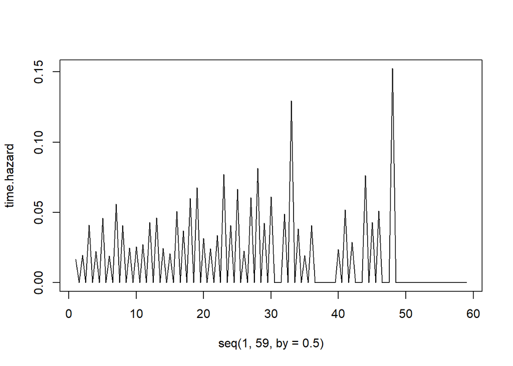

```r
intercept <- coef(est.res)["(Intercept)"]
time.dummy <- coef(est.res)[substr(names(coef(est.res)),1,16)=="factor(duration)"]
time.hazard <- exp(intercept + time.dummy)

plot(seq(1,59,by=0.5),time.hazard,type="l")
```

This model requires a large amount of dummy variables. The estimated time dependent hazard is based on a few data points.

Alternaitvely, we can include the duration variable itself.

```r
est.res <- glm(ciep12 ~ invest + polar + numst2 + crisis  +
              duration
              ,data=cp.data,family=binomial(link="logit"))
summary(est.res)
```

```
##
## Call:
## glm(formula = ciep12 ~ invest + polar + numst2 + crisis + duration,
##     family = binomial(link = "logit"), data = cp.data)
##
## Coefficients:
##              Estimate Std. Error z value Pr(>|z|)
## (Intercept) -4.110573   0.160392 -25.628  < 2e-16 ***
## invest       0.475584   0.138713   3.429 0.000607 ***
## polar        0.039848   0.005578   7.144 9.04e-13 ***
## numst2      -0.532488   0.131316  -4.055 5.01e-05 ***
## crisis      -0.005271   0.002153  -2.448 0.014378 *
## duration     0.008361   0.005712   1.464 0.143222
## ---
## Signif. codes:  0 '***' 0.001 '**' 0.01 '*' 0.05 '.' 0.1 ' ' 1
##
## (Dispersion parameter for binomial family taken to be 1)
##
##     Null deviance: 2570.7  on 11578  degrees of freedom
## Residual deviance: 2463.2  on 11573  degrees of freedom
## AIC: 2475.2
##
## Number of Fisher Scoring iterations: 7
```

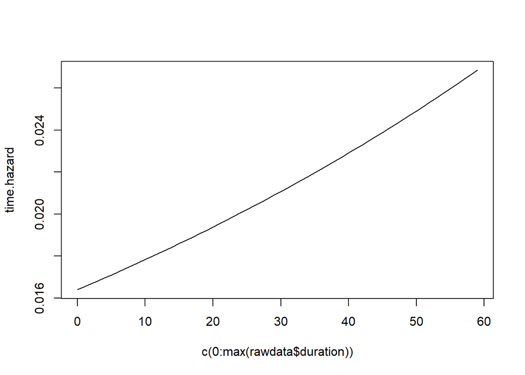

```r
intercept <- coef(est.res)["(Intercept)"]
time.coef <- coef(est.res)["duration"]
time.hazard <- exp(intercept + time.coef * (0:max(cp.data$duration)))

plot(c(0:max(rawdata$duration)),time.hazard,type="l")
```

Note that the estimated time dependent hazard is not linear due to the binary logit model.

The duration variable can be also added after logarithmization:

```r
# ---------------------------------------------------------------------------------------------------
# natural log
est.res <- glm(ciep12 ~ invest + polar + numst2 + crisis +
              log(duration)
              ,data=cp.data,family=binomial(link="logit"))
summary(est.res)
```

```
##
## Call:
## glm(formula = ciep12 ~ invest + polar + numst2 + crisis + log(duration),
##     family = binomial(link = "logit"), data = cp.data)
##
## Coefficients:
##                Estimate Std. Error z value Pr(>|z|)
## (Intercept)   -4.247567   0.202307 -20.996  < 2e-16 ***
## invest         0.481084   0.138603   3.471 0.000519 ***
## polar          0.040233   0.005532   7.272 3.53e-13 ***
## numst2        -0.531578   0.130659  -4.068 4.73e-05 ***
## crisis        -0.005333   0.002155  -2.474 0.013349 *
## log(duration)  0.112261   0.062756   1.789 0.073642 .
## ---
## Signif. codes:  0 '***' 0.001 '**' 0.01 '*' 0.05 '.' 0.1 ' ' 1
##
## (Dispersion parameter for binomial family taken to be 1)
##
##     Null deviance: 2570.7  on 11578  degrees of freedom
## Residual deviance: 2462.0  on 11573  degrees of freedom
## AIC: 2474
##
## Number of Fisher Scoring iterations: 7
```

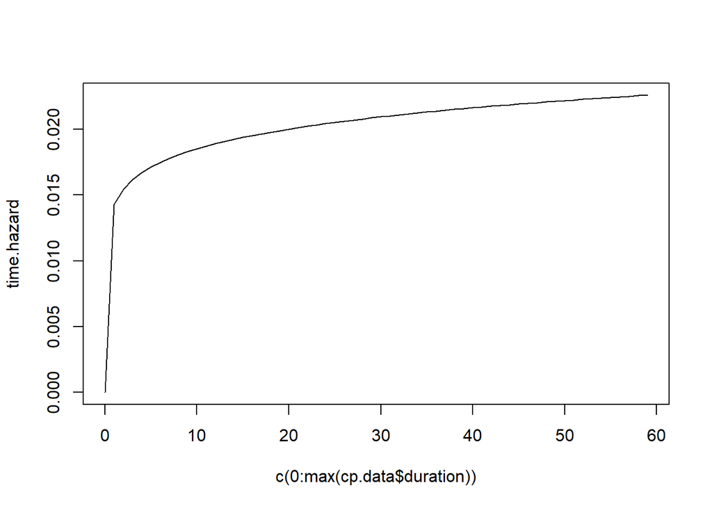

```r
intercept <- coef(est.res)["(Intercept)"]
time.coef <- coef(est.res)["log(duration)"]
time.hazard <- exp(intercept + time.coef * log((0:max(cp.data$duration))))

plot(c(0:max(cp.data$duration)),time.hazard,type="l")
```

Further, the duration variable can be considered in the quadratic function:

```r
durat2 <- cp.data$duration^2
cp.data <- cbind(cp.data,durat2)
est.res <- glm(ciep12 ~ invest + polar + numst2 + crisis +
              duration + durat2
              ,data=cp.data,family=binomial(link="logit"))
summary(est.res)
```

```
##
## Call:
## glm(formula = ciep12 ~ invest + polar + numst2 + crisis + duration +
##     durat2, family = binomial(link = "logit"), data = cp.data)
##
## Coefficients:
##               Estimate Std. Error z value Pr(>|z|)
## (Intercept) -4.3175426  0.1966448 -21.956  < 2e-16 ***
## invest       0.4844504  0.1383682   3.501 0.000463 ***
## polar        0.0405373  0.0055780   7.267 3.66e-13 ***
## numst2      -0.5228205  0.1311696  -3.986 6.72e-05 ***
## crisis      -0.0053522  0.0021567  -2.482 0.013076 *
## duration     0.0408127  0.0181132   2.253 0.024246 *
## durat2      -0.0008179  0.0004386  -1.865 0.062171 .
## ---
## Signif. codes:  0 '***' 0.001 '**' 0.01 '*' 0.05 '.' 0.1 ' ' 1
##
## (Dispersion parameter for binomial family taken to be 1)
##
##     Null deviance: 2570.7  on 11578  degrees of freedom
## Residual deviance: 2459.5  on 11572  degrees of freedom
## AIC: 2473.5
##
## Number of Fisher Scoring iterations: 7
```

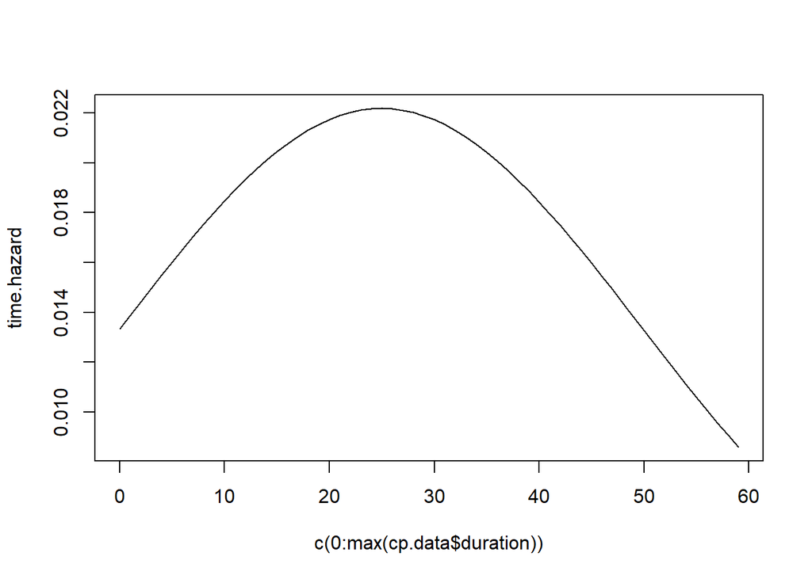

```r
intercept <- coef(est.res)["(Intercept)"]
time.coef <- coef(est.res)["duration"]
time.coef2 <- coef(est.res)["durat2"]
time.hazard <- exp(intercept + time.coef * (0:max(cp.data$duration)) + time.coef2 * (0:max(cp.data$duration))^2 )

plot(c(0:max(cp.data$duration)),time.hazard,type="l")
```

### Cox PH model with count process data

Now we can estimate Cox PH model by using conditional logit model. For this purpose, we first convert the rawdata in the format for clogit. This data is different from the above data:

```r
# ---------------------------------------------------------------------------------------------------
# For Cox regression
# ---------------------------------------------------------------------------------------------------
cut.points <- unique(rawdata$durat[rawdata$censor == 1])
cox.cp.data <- survSplit(data = rawdata.with.id, cut = cut.points,
     end = "duration",start = "time0", event = "ciep12")


head(cp.data,n=20)
```

```
##    id invest fract polar numst2 crisis country time0 duration ciep12 durat2
## 1   1      1   656    11      0     24 belgium   0.0      0.5      1   0.25
## 2   2      1   656    11      1     10 belgium   0.0      0.5      0   0.25
## 3   2      1   656    11      1     10 belgium   0.5      1.0      0   1.00
## 4   2      1   656    11      1     10 belgium   1.0      1.5      0   2.25
## 5   2      1   656    11      1     10 belgium   1.5      2.0      0   4.00
## 6   2      1   656    11      1     10 belgium   2.0      2.5      0   6.25
## 7   2      1   656    11      1     10 belgium   2.5      3.0      1   9.00
## 8   3      1   656    11      1     24 belgium   0.0      0.5      0   0.25
## 9   3      1   656    11      1     24 belgium   0.5      1.0      0   1.00
## 10  3      1   656    11      1     24 belgium   1.0      1.5      0   2.25
## 11  3      1   656    11      1     24 belgium   1.5      2.0      0   4.00
## 12  3      1   656    11      1     24 belgium   2.0      2.5      0   6.25
## 13  3      1   656    11      1     24 belgium   2.5      3.0      0   9.00
## 14  3      1   656    11      1     24 belgium   3.0      3.5      0  12.25
## 15  3      1   656    11      1     24 belgium   3.5      4.0      0  16.00
## 16  3      1   656    11      1     24 belgium   4.0      4.5      0  20.25
## 17  3      1   656    11      1     24 belgium   4.5      5.0      0  25.00
## 18  3      1   656    11      1     24 belgium   5.0      5.5      0  30.25
## 19  3      1   656    11      1     24 belgium   5.5      6.0      0  36.00
## 20  3      1   656    11      1     24 belgium   6.0      6.5      0  42.25
```

```r
head(cox.cp.data,n=20)
```

```
##    id invest fract polar numst2 crisis country time0 duration ciep12
## 1   1      1   656    11      0     24 belgium     0      0.5      1
## 2   2      1   656    11      1     10 belgium     0      3.0      1
## 3   3      1   656    11      1     24 belgium     0      7.0      1
## 4   4      1   656    11      1      7 belgium     0     20.0      1
## 5   5      1   656    11      1      7 belgium     0      6.0      1
## 6   6      1   634     6      1     45 belgium     0      7.0      1
## 7   7      1   599     3      1     51 belgium     0      2.0      1
## 8   8      1   599     3      1      4 belgium     0     17.0      1
## 9   9      1   599     3      1      6 belgium     0     27.0      1
## 10 10      1   620     2      1     10 belgium     0     49.0      0
## 11 11      1   592     1      0     23 belgium     0      4.0      1
## 12 12      1   592     1      1      2 belgium     0     29.0      1
## 13 13      1   628     5      1     29 belgium     0     49.0      0
## 14 14      1   719    11      1     65 belgium     0      6.0      1
## 15 15      1   719    11      1     38 belgium     0     23.0      1
## 16 16      1   757    18      1    132 belgium     0     41.0      0
## 17 17      1   775    24      1     73 belgium     0     10.0      1
## 18 18      1   775    24      1     61 belgium     0     12.0      1
## 19 19      1   762    24      0     65 belgium     0      2.0      1
## 20 20      1   762    24      1      0 belgium     0     33.0      1
```

Now we can estimate the Cox model by using clogit:

```r
clogit(ciep12 ~ invest + polar +
              numst2 + crisis +
              strata(time0) ,
              method="exact",
              data=cox.cp.data)
```

```
## Call:
## clogit(ciep12 ~ invest + polar + numst2 + crisis + strata(time0),
##     method = "exact", data = cox.cp.data)
##
##             coef exp(coef)  se(coef)      z        p
## invest  1.197006  3.310192  0.436628  2.741 0.006116
## polar   0.078539  1.081706  0.022128  3.549 0.000386
## numst2 -1.345645  0.260372  0.454492 -2.961 0.003069
## crisis -0.008358  0.991677  0.004343 -1.924 0.054293
##
## Likelihood ratio test=46.13  on 4 df, p=2.309e-09
## n= 314, number of events= 271
```

For comparison, we can estimate again the same model by using coxph().

```r
# ---------------------------------------------------------------------------------------------------
# Comparison with coxph()
est.res <- coxph(Surv(duration,ciep12) ~ invest + polar +
              numst2 + crisis,
              ties="exact",
              data=rawdata)
print(est.res)
```

```
## Call:
## coxph(formula = Surv(duration, ciep12) ~ invest + polar + numst2 +
##     crisis, data = rawdata, ties = "exact")
##
##             coef exp(coef)  se(coef)      z        p
## invest  0.499325  1.647608  0.140566  3.552 0.000382
## polar   0.041353  1.042220  0.005699  7.257 3.97e-13
## numst2 -0.533184  0.586734  0.133768 -3.986 6.72e-05
## crisis -0.005337  0.994677  0.002192 -2.435 0.014896
##
## Likelihood ratio test=104.6  on 4 df, p=< 2.2e-16
## n= 314, number of events= 271
```

## Flexible parametric model: Royceton-Palmer

We first estimate the spline with k=0, which is equivalent to Weibul model.

```r
est.res.k0 <- flexsurvspline(Surv(duration,ciep12) ~ invest + polar +
                   numst2 + crisis ,data=rawdata,
                   k=0,scale="hazard")
print(est.res.k0)
```

```
## Call:
## flexsurvspline(formula = Surv(duration, ciep12) ~ invest + polar +
##     numst2 + crisis, data = rawdata, k = 0, scale = "hazard")
##
## Estimates:
##         data mean  est       L95%      U95%      se        exp(est)  L95%
## gamma0        NA   -3.82363  -4.27849  -3.36877   0.23208        NA        NA
## gamma1        NA    1.15619   1.04316   1.26922   0.05767        NA        NA
## invest   0.45223    0.47615   0.20844   0.74385   0.13659   1.60986   1.23176
## polar   15.28981    0.04018   0.02958   0.05079   0.00541   1.04100   1.03002
## numst2   0.63057   -0.52529  -0.77612  -0.27447   0.12797   0.59138   0.46019
## crisis  22.38217   -0.00540  -0.00957  -0.00123   0.00213   0.99462   0.99048
##         U95%
## gamma0        NA
## gamma1        NA
## invest   2.10402
## polar    1.05210
## numst2   0.75997
## crisis   0.99877
##
## N = 314,  Events: 271,  Censored: 43
## Total time at risk: 5789.5
## Log-likelihood = -1045.671, df = 6
## AIC = 2103.341
```

For comparison, here is the result of the above Weibull model:

```r
flexsurvreg(formula =Surv(duration,ciep12) ~ invest + polar +
                   numst2 + crisis, data = rawdata, dist = "weibullph")
```

```
## Call:
## flexsurvreg(formula = Surv(duration, ciep12) ~ invest + polar +
##     numst2 + crisis, data = rawdata, dist = "weibullph")
##
## Estimates:
##         data mean  est       L95%      U95%      se        exp(est)  L95%
## shape         NA    1.15619   1.04851   1.27493   0.05767        NA        NA
## scale         NA    0.02185   0.01386   0.03443   0.00507        NA        NA
## invest   0.45223    0.47616   0.20845   0.74386   0.13659   1.60988   1.23177
## polar   15.28981    0.04018   0.02958   0.05079   0.00541   1.04100   1.03002
## numst2   0.63057   -0.52530  -0.77612  -0.27448   0.12797   0.59138   0.46019
## crisis  22.38217   -0.00540  -0.00956  -0.00124   0.00212   0.99462   0.99049
##         U95%
## shape         NA
## scale         NA
## invest   2.10404
## polar    1.05210
## numst2   0.75997
## crisis   0.99876
##
## N = 314,  Events: 271,  Censored: 43
## Total time at risk: 5789.5
## Log-likelihood = -1045.671, df = 6
## AIC = 2103.341
```

Note that here the parametrization is based on PH and not AFT like the estimate above.

Now, we can introduce the knot point, which varies between 1 and 10:

```r
all.royceton <- vector("list",11)
all.royceton[[1]] <- est.res.k0

for (k in 1:10){
  all.royceton[[k+1]] <- flexsurvspline(Surv(duration,ciep12) ~ invest + polar +
                   numst2 +  crisis,data=rawdata,
                   k=k,scale="hazard")

}

all.para.label <- names(all.royceton[[11]]$coefficients)

all.results <- NULL
for (k in 0:10){
  temp.result <- cbind(all.royceton[[k+1]]$coefficients,sqrt(diag(all.royceton[[k+1]]$cov)))
  key <- match(all.para.label , rownames(temp.result))
  all.results <- cbind(all.results,temp.result[key,])
}

rownames(all.results) <- all.para.label

col.label  <- paste0("k=",0:10)

colnames(all.results) <- rep("",22)
colnames(all.results)[seq(1,21,by=2)] <- col.label

print(all.results,digits=3)
```

```
##             k=0              k=1              k=2              k=3
## gamma0  -3.8236 0.23208 -3.90213 0.27374 -3.91207 0.27810 -3.91860 0.27989
## gamma1   1.1562 0.05767  1.23287 0.14916  1.25722 0.19724  1.32844 0.23173
## gamma2       NA      NA  0.00894 0.01585  0.01561 0.07509  0.10819 0.12656
## gamma3       NA      NA       NA      NA -0.01025 0.10604 -0.29620 0.33979
## gamma4       NA      NA       NA      NA       NA      NA  0.27158 0.32135
## gamma5       NA      NA       NA      NA       NA      NA       NA      NA
## gamma6       NA      NA       NA      NA       NA      NA       NA      NA
## gamma7       NA      NA       NA      NA       NA      NA       NA      NA
## gamma8       NA      NA       NA      NA       NA      NA       NA      NA
## gamma9       NA      NA       NA      NA       NA      NA       NA      NA
## gamma10      NA      NA       NA      NA       NA      NA       NA      NA
## gamma11      NA      NA       NA      NA       NA      NA       NA      NA
## invest   0.4761 0.13659  0.47342 0.13667  0.47320 0.13669  0.47339 0.13658
## polar    0.0402 0.00541  0.03970 0.00547  0.03972 0.00548  0.03976 0.00547
## numst2  -0.5253 0.12797 -0.51957 0.12833 -0.52069 0.12863 -0.51635 0.12861
## crisis  -0.0054 0.00213 -0.00534 0.00213 -0.00534 0.00213 -0.00531 0.00212
##              k=4              k=5              k=6              k=7
## gamma0  -3.94605 0.28003 -3.93295 0.28154 -3.91044 0.28077 -3.90111 0.280991
## gamma1   1.23567 0.24438  1.28674 0.27038  1.33623 0.28225  1.36087 0.292464
## gamma2  -0.15999 0.20697 -0.00752 0.19822  0.18030 0.28733  0.41388 0.490648
## gamma3   0.63809 0.48496 -0.00182 0.59416 -0.89077 0.98010 -1.37443 1.462968
## gamma4  -1.26234 0.72008  0.70460 1.20888  1.78103 1.68607  1.59338 1.834747
## gamma5   1.02914 0.56846 -2.17217 1.70810 -1.27914 2.12304 -0.48745 2.521758
## gamma6        NA      NA  1.85174 1.13843 -0.75280 2.15007 -0.26228 3.716630
## gamma7        NA      NA       NA      NA  1.38910 1.26214 -1.08992 3.518677
## gamma8        NA      NA       NA      NA       NA      NA  1.72757 1.842061
## gamma9        NA      NA       NA      NA       NA      NA       NA       NA
## gamma10       NA      NA       NA      NA       NA      NA       NA       NA
## gamma11       NA      NA       NA      NA       NA      NA       NA       NA
## invest   0.47327 0.13647  0.47455 0.13644  0.47547 0.13641  0.47571 0.136401
## polar    0.04000 0.00548  0.04004 0.00546  0.04013 0.00546  0.04010 0.003948
## numst2  -0.51481 0.12850 -0.51369 0.12848 -0.51415 0.12847 -0.51422 0.128463
## crisis  -0.00532 0.00213 -0.00532 0.00122 -0.00534 0.00123 -0.00534 0.000566
##              k=8               k=9             k=10
## gamma0  -3.90761 0.281987 -3.87386 0.28773 -3.86574 0.28847
## gamma1   1.34209 0.290907  1.41401 0.32493  1.42552 0.32855
## gamma2   0.22813 0.552319  0.19671 0.38899  0.26310 0.48398
## gamma3  -0.40606 2.043685  0.07103 1.30282 -0.11716 3.26523
## gamma4  -0.89855 3.828036 -1.95361 2.73595 -0.93200 5.14107
## gamma5   2.59631 3.702986  3.19142 3.13785  1.41950 4.10436
## gamma6  -2.57798 3.322868 -1.79190 4.33800 -1.13605 4.51213
## gamma7   2.17134 4.719282 -0.94961 6.33008  3.86654 7.23113
## gamma8  -3.37767 5.144204  2.94784 7.04332 -8.39811 9.42283
## gamma9   2.95057 2.745474 -4.41154 6.38025  7.85159 8.33212
## gamma10       NA       NA  3.52727 3.24843 -6.12656 6.34051
## gamma11       NA       NA       NA      NA  4.26544 3.53820
## invest   0.47578 0.136373  0.47605 0.13635  0.47525 0.13636
## polar    0.04012 0.003951  0.04012 0.00396  0.04008 0.00396
## numst2  -0.51246 0.128444 -0.51271 0.12842 -0.51253 0.12842
## crisis  -0.00536 0.000802 -0.00536 0.00113 -0.00537 0.00147
```

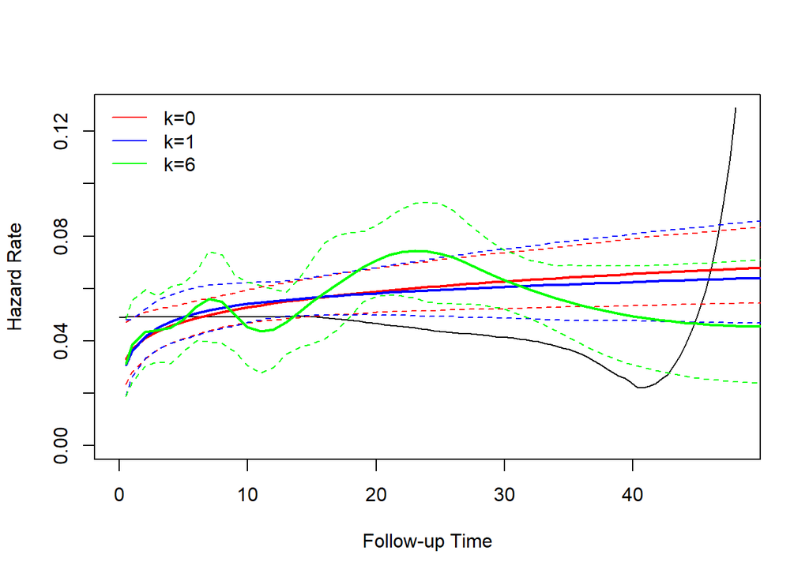

```r
plot(all.royceton[[1]],ci=TRUE,type="hazard",col="red")

lines(all.royceton[[2]],ci=TRUE,type="hazard",col="blue")

lines(all.royceton[[7]],ci=TRUE,type="hazard"
      ,col="green")
legend("topleft",lty=1,col=c("red","blue","green"),c("k=0","k=1","k=6"),bty="n")
```

## Model diagnostics

Again, we first estimate a Cox model:

```r
est.res <- coxph(Surv(duration,ciep12) ~ invest + polar +
              numst2 + crisis,
              ties="exact",
              data=rawdata)
print(est.res)
```

```
## Call:
## coxph(formula = Surv(duration, ciep12) ~ invest + polar + numst2 +
##     crisis, data = rawdata, ties = "exact")
##
##             coef exp(coef)  se(coef)      z        p
## invest  0.499325  1.647608  0.140566  3.552 0.000382
## polar   0.041353  1.042220  0.005699  7.257 3.97e-13
## numst2 -0.533184  0.586734  0.133768 -3.986 6.72e-05
## crisis -0.005337  0.994677  0.002192 -2.435 0.014896
##
## Likelihood ratio test=104.6  on 4 df, p=< 2.2e-16
## n= 314, number of events= 271
```

Most diagnostics rely on the residuals from the result above. Event history models know various kinds of residuals. For the output object produced by **coxph()** we can use **resid()** to easily obtain the following residuals:

- martingale
- deviance
- score
- schoenfeld
- dfbeta
- dfbetas
- scaledsch
- partial

### Cox Snell residuals

Cox-Snell residuals are defined as the estimated integrated hazard: $r_{CS_i}= \hat H_i = \exp(\hat{\beta}'{x}_i) \hat{H}_0(t_i)$ with $\hat{H}_0(t_i) = - \log \hat{S}_0(t) = - \sum_i \log \left( \sum_{j \in R(t_i)} e^{\beta' {x}_j}\right)$ (integrated baseline hazard).

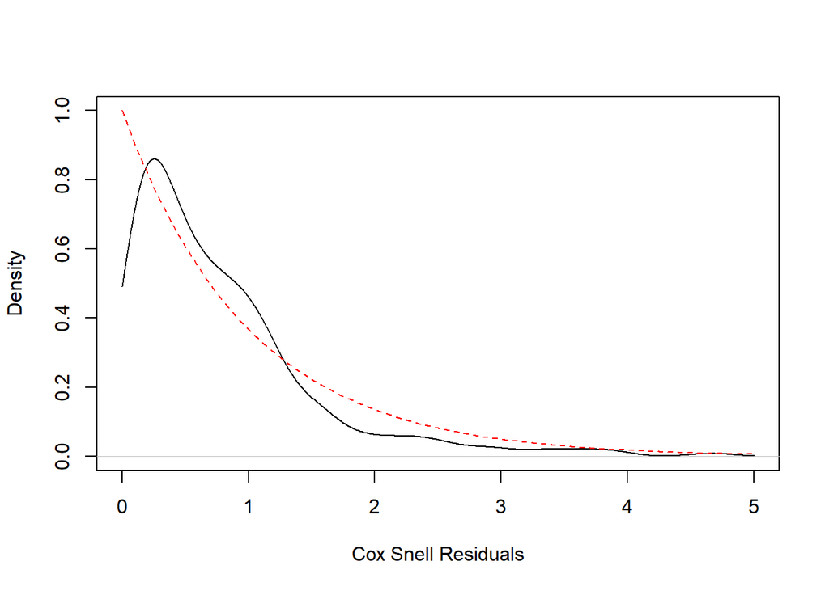

```r
### calculate cox snell from martingale
cox.snell <- rawdata$ciep12-resid(est.res,type="martingale")

plot(density(cox.snell[rawdata$ciep12==1],from=0,to=5),ylim=c(0,1),ylab="Density",xlab="Cox Snell Residuals",main="")
exponential.func <- function(x) dexp(x,1)
curve(exponential.func,0,5,ylab="f(x)",add=T,col="red",lty=2)
```

If the model is correct, Cox-Snell residuals should be distributed according to the unit exponential distribution (red dotted line in the figure). If it is the case, the cumulative hazard based on the Cox-Snell residuals $H_r(r_{CS})$ should correspond to the Cox-Snell residuals themselves. To obtain $H_r(r_{CS})$, we can use the relationship: $H_r(r_{CS}) = - \log S_r(r_{CS})$. The corresponding survival function based on Cox-Snell can be obtained by using the Kaplan-Meier-estimator.

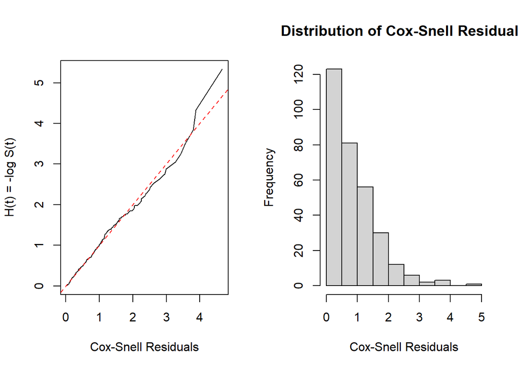

```r
## estimate the cumulative hazard function for residuals;
H.t <- survfit(coxph(Surv(cox.snell,rawdata$ciep12)~1,method='breslow'),stype=2,ctype=2)

par(mfrow=c(1,2))
plot(H.t$time,-log(H.t$surv),type='l',xlab='Cox-Snell Residuals',
    ylab="H(t) = -log S(t)",
    main="")
abline(0,1,col='red',lty=2)

hist(cox.snell,main="Distribution of Cox-Snell Residuals",xlab="Cox-Snell Residuals")
```

The red dotted line in the left-hand panel is the 45-degree line. If the plot is close to the line, Cox-Snell residuals are likely to be distributed according to the unit exponential. There is a larger deviation from the 45-degree line in the range with $r_{CS}>4$, however as the right-hand panel shows, there are only one case there.

#### Martingale Residuals

Martingale residuals are more intuitive than the Cox-Snell residuals. If the data is represented the counting process, the Martingale residuals are defined as: $M_i(t) = \delta_i - H_i(t) = \delta_i - r_{CS_i}$.

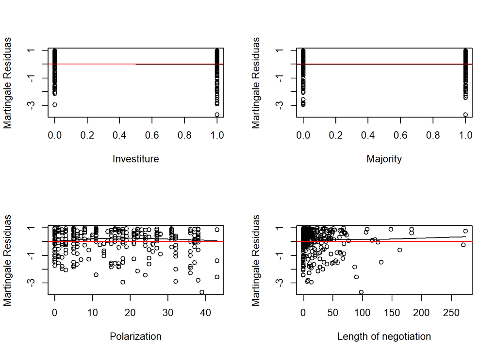

```r
res.m <- residuals(est.res,type="martingale")
par(mfrow=c(2,2))
plot(res.m ~ rawdata$invest,ylab="Martingale Residuas",xlab="Investiture")
abline(lm(res.m ~ rawdata$invest))
abline(h=0,col="red")
plot(res.m ~ rawdata$numst2,ylab="Martingale Residuas",xlab="Majority")
abline(lm(res.m ~ rawdata$numst2))
abline(h=0,col="red")

scatter.smooth(rawdata$polar,res.m,ylab="Martingale Residuas",xlab="Polarization")
abline(h=0,col="red")
scatter.smooth(rawdata$crisis,res.m,ylab="Martingale Residuas",xlab="Length of negotiation")
abline(h=0,col="red")
```

The expected martingale residuals conditioned by the different covariates are close to zero, which implies no need to change the linear function in the model.

#### Poorly prediced obaservations based on deviance residuals

Martingale residuals have an asymmetrical range between $-\infty$ and $1$, therefore they are strongly skewed. Deviance residuals are rescaled Martingale, which is more symmetrical: $D_i= sign(M_i(t))\sqrt{-2 \left[ M_i(t) + \delta_i \log(\delta_i-M_i(t) ) \right]}$.

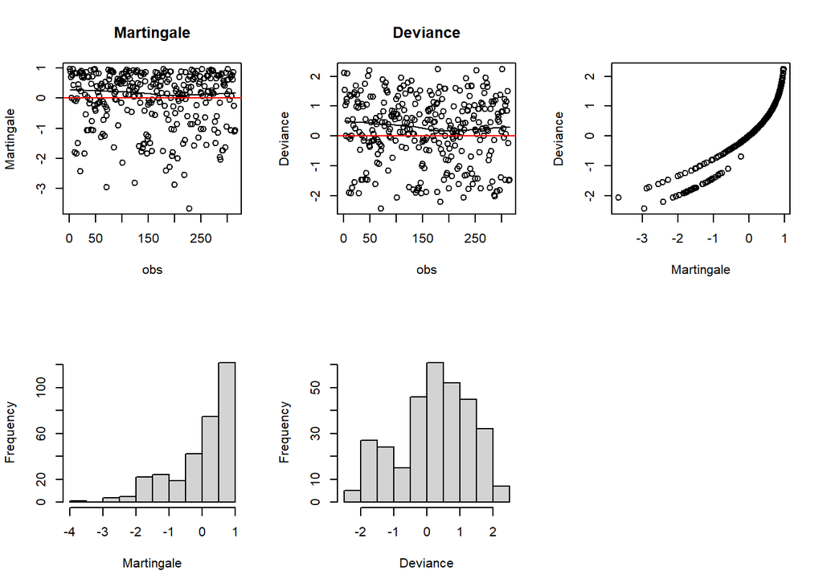

```r
res.dev <- residuals(est.res,type="deviance")

par(mfcol=c(2,3))
scatter.smooth(res.m,ylab="Martingale",xlab="obs",main="Martingale")
abline(h=0,col="red")
hist(res.m,main="",xlab="Martingale")
scatter.smooth(res.dev,ylab="Deviance",xlab="obs",main="Deviance")
abline(h=0,col="red")
hist(res.dev,main="",xlab="Deviance")

plot(res.m,res.dev ,xlab="Martingale",ylab="Deviance")
```

To detect the poorly predicted observations, we can plot the deviance residuals against the duration time:

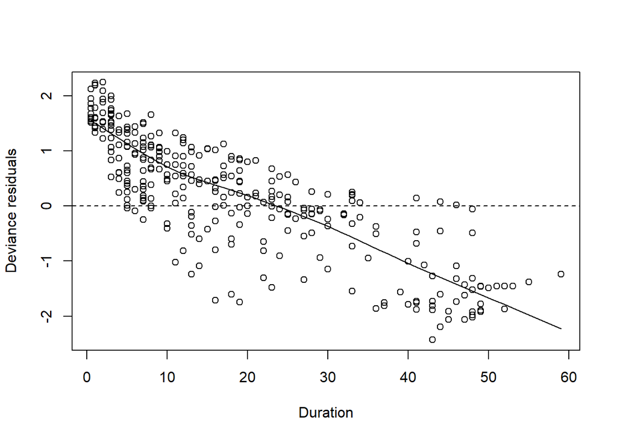

```r
scatter.smooth(rawdata$duration,res.dev,xlab="Duration",ylab="Deviance residuals")
abline(h=0,lty=2)
```

```r
#par(mfrow=c(1,2))
#scatter.smooth(rawdata$polar,res.dev)
#scatter.smooth(rawdata$crisis,res.dev)
```

The plot gives a systematic relationship between residuals and duration. The cabinets with a short duration tend to have positive deviance residuals, which means these cabinets are predicted to survive longer than observed. Conversely, the cabinets which survived longer tend to be predicted to survive shorter. This can indicate a possible violation of PH property since there is a systematic difference in residuals over time.

#### Outlier detection based on the score residuals

The score residuals are obtained case- and covariate-specific. Given we are interested in the covariate $X$, $i$’s case residual is in the counting process representation: $L_i = \int^\infty_0 [X_i(t) - \bar{X}_i (t)] d\hat{M}_i(t)$. $\bar{X}_i (t)$ is the weighted mean of $X$ in the risk set at $t$, and $d\hat{M}_i(t)$ is the change in martingale residuals for $i$ at $t$.

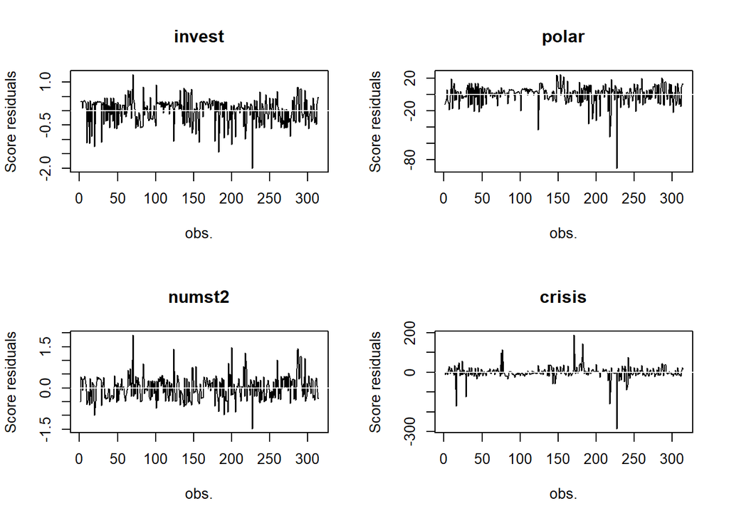

```r
est.res <- coxph(Surv(duration,ciep12) ~ invest + polar +
              numst2 + crisis,
              #ties="exact", ## score is not available for the exact method for tie events.
              data=rawdata)

res.score <- residuals(est.res,type="score")

par(mfrow=c(2,2))
for (i in 1:4){
  plot(res.score[,i],type="l",xlab="obs.",ylab="Score residuals",main=names(coef(est.res))[i])
  abline(h=0,col="white")
}
```

Here we see some observations which have a stronger impact on the coefficients, but it is hard to interpret the value itself. It is easier to interpret if we standardize the scale:

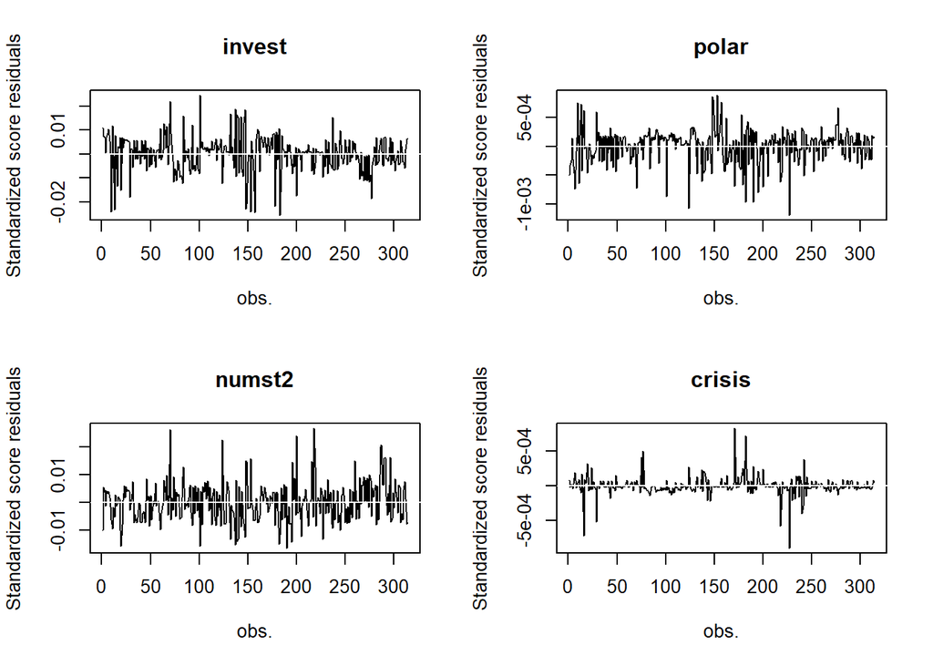

```r
res.dfbeta <- residuals(est.res,type="dfbeta")

par(mfrow=c(2,2))
for (i in 1:4){
  plot(res.dfbeta[,i],type="l",xlab="obs.",ylab="Standardized score residuals",main=names(coef(est.res))[i])
  abline(h=0,col="white")
}
```

The scales on the y-axes inform that the impact of individual cases is quite limited and its highest impact changes only 2% of the coefficients.

#### Testing the PH property via piecewise regression

The most straightforward way to check the PH assumption is to repeat the analysis based on the subsamples with different duration.

Here, we can divide the data into two subdata with the almost same size:

- duration shorter than 15 months (n=160)
- duration not shorter than 15 months (n=154)

```r
all.res <- NULL
for (i in 1:3){

    if (i==1) this.data <- rawdata
    if (i==2) this.data <- rawdata[rawdata$duration<15,]
    if (i==3) this.data <- rawdata[rawdata$duration>=15,]
    est.res <- coxph(Surv(duration,ciep12) ~ invest + polar +
                  numst2 + crisis,
                  ties="exact",
                  data=this.data)
    print(c("All observations","duration < 15","duration >= 15")[i])
    print(est.res)
    print("-------------------------------------------")
    all.res <- rbind(all.res,coef(summary(est.res))[,c(1,3)])
}
```

```
## [1] "All observations"
## Call:
## coxph(formula = Surv(duration, ciep12) ~ invest + polar + numst2 +
##     crisis, data = this.data, ties = "exact")
##
##             coef exp(coef)  se(coef)      z        p
## invest  0.499325  1.647608  0.140566  3.552 0.000382
## polar   0.041353  1.042220  0.005699  7.257 3.97e-13
## numst2 -0.533184  0.586734  0.133768 -3.986 6.72e-05
## crisis -0.005337  0.994677  0.002192 -2.435 0.014896
##
## Likelihood ratio test=104.6  on 4 df, p=< 2.2e-16
## n= 314, number of events= 271
## [1] "-------------------------------------------"
## [1] "duration < 15"
## Call:
## coxph(formula = Surv(duration, ciep12) ~ invest + polar + numst2 +
##     crisis, data = this.data, ties = "exact")
##
##             coef exp(coef)  se(coef)      z      p
## invest  0.556289  1.744188  0.229748  2.421 0.0155
## polar   0.000162  1.000162  0.008290  0.020 0.9844
## numst2 -0.278328  0.757048  0.185814 -1.498 0.1342
## crisis -0.004815  0.995197  0.003468 -1.388 0.1650
##
## Likelihood ratio test=10.04  on 4 df, p=0.0398
## n= 160, number of events= 160
## [1] "-------------------------------------------"
## [1] "duration >= 15"
## Call:
## coxph(formula = Surv(duration, ciep12) ~ invest + polar + numst2 +
##     crisis, data = this.data, ties = "exact")
##
##             coef exp(coef)  se(coef)      z        p
## invest  0.485975  1.625759  0.210242  2.312   0.0208
## polar   0.041191  1.042051  0.010109  4.075 4.61e-05
## numst2 -0.596513  0.550729  0.218352 -2.732   0.0063
## crisis -0.005472  0.994543  0.003477 -1.574   0.1155
##
## Likelihood ratio test=28.39  on 4 df, p=1.041e-05
## n= 154, number of events= 111
## [1] "-------------------------------------------"
```

The estimates can be compared in the following figure:

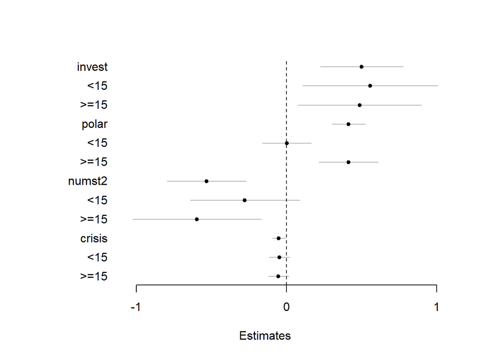

```r
source("https://raw.githubusercontent.com/SuShikano/SusumuMiscR/main/R/Coef_CI_Plot.R")

all.res <- all.res[c(1,5,9,2,6,10,3,7,11,4,8,12),]
all.res[c(4:6,10:12),] <- all.res[c(4:6,10:12),]*10
rownames(all.res)[c(2,3,5,6,8,9,11,12)] <- rep(c("<15",">=15"),4)


coef.ci(estimates = all.res[,1],se=all.res[,2],
        var.labels = rownames(all.res),xlab="Estimates")
abline(v=0,lty=2)
```

Accordingly, two variables, polarization and majority status, have smaller, and no significant effects on the risk if we only consider the duration under 15 months. This indicates possible violation of the PH assumption.

#### Testing the PH property via Schoenfeld Residuals

While the above piecewise regression is straightforward, its result depends on how one divide the data. Alternatively, we can also utilize Schoenfeld residuals to check the PH assumption.

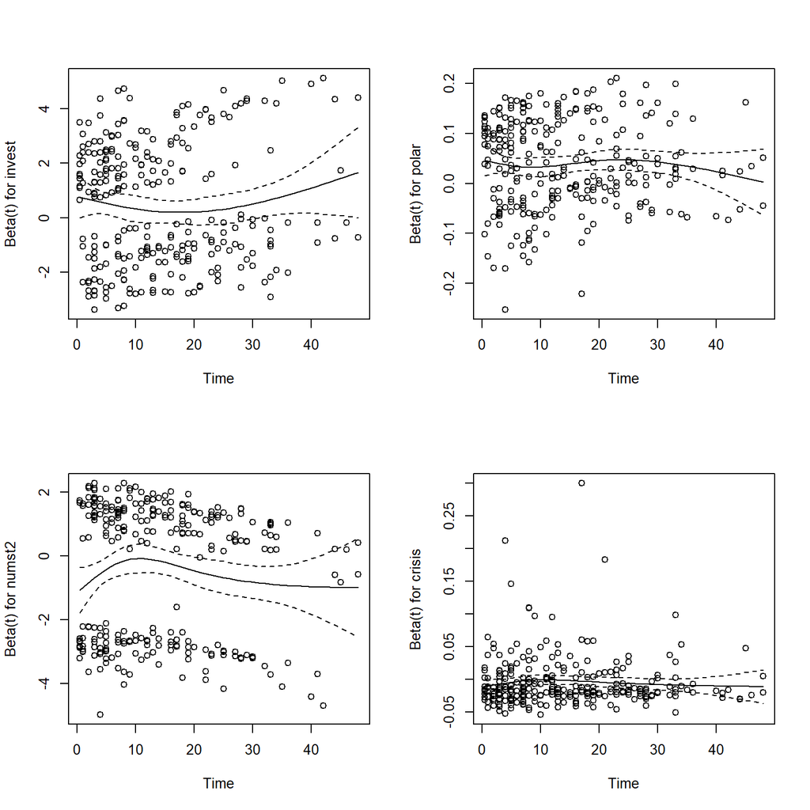

```r
est.res <- coxph(Surv(duration,ciep12) ~ invest + polar +
              numst2 + crisis,
              ties="exact",
              data=rawdata)

par(mfrow=c(2,2))
plot(cox.zph(est.res, transform="identity"))
```

According to the plot, there are no clear patterns of residuals over time, which indicates no violation of the PH assumption. The results can also be quantified in a statistical test:

```r
test.res <- cox.zph(est.res, transform="identity")
test.res
```

```
##          chisq df    p
## invest 0.00587  1 0.94
## polar  0.08149  1 0.78
## numst2 0.52891  1 0.47
## crisis 0.22279  1 0.64
## GLOBAL 0.73849  4 0.95
```

Accordingly, none of the covariates nor the global test indicates any significant violation of the PH assumption.

## Heterogeneity in the data

### Robust standard error based on the Sandwitch estimator

```r
table(rawdata$country)
```

```
##
##     belgium      canada     denmark     finland      france     iceland
##          30          16          24          31          29          17
##     ireland      israel       italy netherlands      norway       spain
##          15          24          41          17          20           3
##      sweden          uk     unknown
##          20          17          10
```

The individual cabinets included in the dataset here are clustered in countries, while we have not considered any country-specific factors. This might have caused some errors in the estimates and underestimation of their standard errors in the results of the naive Cox model below.

```r
est.res <- coxph(Surv(duration,ciep12) ~ invest + polar +
              numst2 + crisis,
              robust=FALSE,
              data=rawdata)
print(est.res)
```

```
## Call:
## coxph(formula = Surv(duration, ciep12) ~ invest + polar + numst2 +
##     crisis, data = rawdata, robust = FALSE)
##
##             coef exp(coef)  se(coef)      z        p
## invest  0.477237  1.611616  0.136486  3.497 0.000471
## polar   0.039936  1.040744  0.005485  7.282 3.30e-13
## numst2 -0.506027  0.602886  0.128464 -3.939 8.18e-05
## crisis -0.005312  0.994702  0.002133 -2.491 0.012745
##
## Likelihood ratio test=104.2  on 4 df, p=< 2.2e-16
## n= 314, number of events= 271
```

To deal with possible heterogeneity, we can estimate the robust standard errors by using the Sandwich-estimator:

```r
est.res <- coxph(Surv(duration,ciep12) ~ invest + polar +
              numst2 + crisis,
              robust=TRUE,
              data=rawdata)
print(est.res)
```

```
## Call:
## coxph(formula = Surv(duration, ciep12) ~ invest + polar + numst2 +
##     crisis, data = rawdata, robust = TRUE)
##
##             coef exp(coef)  se(coef) robust se      z        p
## invest  0.477237  1.611616  0.136486  0.131978  3.616 0.000299
## polar   0.039936  1.040744  0.005485  0.005347  7.469 8.10e-14
## numst2 -0.506027  0.602886  0.128464  0.125492 -4.032 5.52e-05
## crisis -0.005312  0.994702  0.002133  0.002428 -2.188 0.028690
##
## Likelihood ratio test=104.2  on 4 df, p=< 2.2e-16
## n= 314, number of events= 271
```

Further, we can also take into account the clustering based on countries:

```r
est.res <- coxph(Surv(duration,ciep12) ~ invest + polar +
              numst2 + crisis,
              cluster=country,
              data=rawdata)
print(est.res)
```

```
## Call:
## coxph(formula = Surv(duration, ciep12) ~ invest + polar + numst2 +
##     crisis, data = rawdata, cluster = country)
##
##             coef exp(coef)  se(coef) robust se      z        p
## invest  0.477237  1.611616  0.136486  0.196971  2.423   0.0154
## polar   0.039936  1.040744  0.005485  0.008114  4.922 8.58e-07
## numst2 -0.506027  0.602886  0.128464  0.160371 -3.155   0.0016
## crisis -0.005312  0.994702  0.002133  0.002871 -1.850   0.0643
##
## Likelihood ratio test=104.2  on 4 df, p=< 2.2e-16
## n= 314, number of events= 271
```

### Frailty model

In the above analysis, we only corrected the standard errors. We can now estimate another model by introducing frailty.

```r
library(frailtyEM)
est.res.frail <- emfrail(Surv(duration,ciep12) ~ invest + polar +
              numst2 + crisis + cluster(country),
                data=rawdata, distribution=emfrail_dist(dist="gamma"))
summary(est.res.frail)
```

```
## Call:
## emfrail(formula = Surv(duration, ciep12) ~ invest + polar + numst2 +
##     crisis + cluster(country), data = rawdata, distribution = emfrail_dist(dist = "gamma"))
##
## Regression coefficients:
##            coef exp(coef) se(coef)  adj. se        z    p
## invest  0.48305   1.62101  0.19939  0.19942  2.42225 0.02
## polar   0.04068   1.04152  0.00769  0.00771  5.27778 0.00
## numst2 -0.56618   0.56769  0.13828  0.14076 -4.02224 0.00
## crisis -0.00504   0.99497  0.00217  0.00217 -2.32734 0.02
## Estimated distribution: gamma / left truncation: FALSE
##
## Fit summary:
## Commenges-Andersen test for heterogeneity: p-val  0.0274
## no-frailty Log-likelihood: -1326.897
## Log-likelihood: -1324.028
## LRT: 1/2 * pchisq(5.74), p-val 0.0083
##
## Frailty summary:
##                    estimate lower 95% upper 95%
## Var[Z]                0.064     0.007     0.240
## Kendall's tau         0.031     0.003     0.107
## Median concordance    0.030     0.003     0.104
## E[logZ]              -0.033    -0.125    -0.003
## Var[logZ]             0.066     0.007     0.272
## theta                15.549     4.159   149.731
## Confidence intervals based on the likelihood function
```

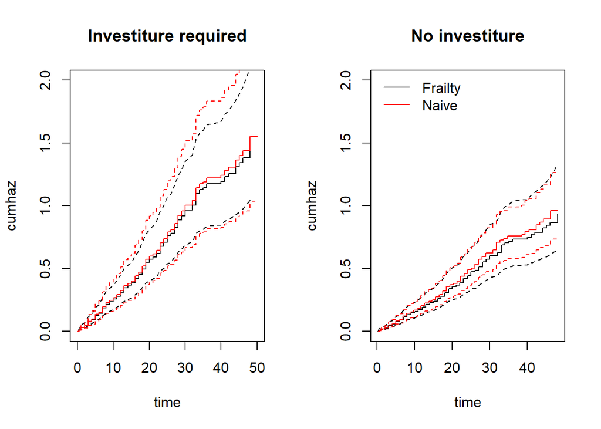

```r
par(mfcol=c(1,2))
plot(est.res.frail,
     newdata=data.frame(invest=1,polar=0,numst2=1,crisis=30
                                ),
     type="pred",type_pred = "marginal",
     main="Investiture required",ylim=c(0,2),xlim=c(0,50))
par(new=T)
plot(survfit(est.res,
             newdata=data.frame(invest=1,polar=0,numst2=1,crisis=30
                                )),fun="cumhaz",main="Naive Cox",ylab="Cumulative hazard",ylim=c(0,2),xlim=c(0,50),col="red",ann=F,axes=F)

plot(est.res.frail,
     newdata=data.frame(invest=0,polar=0,numst2=1,crisis=30
                                ),
     type="pred",,type_pred = "marginal",
     main="No investiture",ylim=c(0,2))
par(new=T)

plot(survfit(est.res,
             newdata=data.frame(invest=0,polar=0,numst2=1,crisis=30
                                )),fun="cumhaz",ylab="Cumulative hazard",ylim=c(0,2),xlim=c(0,50),col="red",ann=F,axes=F)

legend("topleft",col=c("black","red"),lty=1,c("Frailty","Naive"),bty="n")
```